# ANCOVA in Vocabulary not taught (Vocabulary not taught)

Geiser C. Challco geiser@alumni.usp.br

- Setting Initial Variables
- Descriptive Statistics of Initial Data
- ANCOVA and Pairwise for one factor: **grupo**
  - Without remove non-normal data
  - Computing ANCOVA and PairWise After removing non-normal data (OK)
    - Plots for ancova
    - Checking linearity assumption
    - Checking normality and homogeneity
- ANCOVA and Pairwise for two factors **grupo:Sexo**
  - Without remove non-normal data
  - Computing ANCOVA and PairWise After removing non-normal data (OK)
    - Plots for ancova
    - Checking linearity assumption
    - Checking normality and homogeneity
- ANCOVA and Pairwise for two factors **grupo:Zona**
  - Without remove non-normal data
  - Computing ANCOVA and PairWise After removing non-normal data (OK)
    - Plots for ancova
    - Checking linearity assumption
    - Checking normality and homogeneity
- ANCOVA and Pairwise for two factors **grupo:Cor.Raca**
  - Without remove non-normal data
  - Computing ANCOVA and PairWise After removing non-normal data (OK)
    - Plots for ancova
    - Checking linearity assumption
    - Checking normality and homogeneity
- ANCOVA and Pairwise for two factors **grupo:Serie**
  - Without remove non-normal data
  - Computing ANCOVA and PairWise After removing non-normal data (OK)
    - Plots for ancova
    - Checking linearity assumption
    - Checking normality and homogeneity
- ANCOVA and Pairwise for two factors **grupo:vocab.non.teach.quintile**
  - Without remove non-normal data
  - Computing ANCOVA and PairWise After removing non-normal data (OK)
    - Plots for ancova
    - Checking linearity assumption
    - Checking normality and homogeneity
- Summary of Results
  - Descriptive Statistics
  - ANCOVA Table Comparison
  - PairWise Table Comparison
  - EMMS Table Comparison

**NOTE**:

- Teste ANCOVA para determinar se houve diferenças significativas no Vocabulary not taught (medido usando pre- e pos-testes).
- ANCOVA test to determine whether there were significant differences in Vocabulary not taught (measured using pre- and post-tests).

# Setting Initial Variables

```r
dv = "vocab.non.teach"
dv.pos = "vocab.non.teach.pos"
dv.pre = "vocab.non.teach.pre"

fatores2 <- c("Sexo","Zona","Cor.Raca","Serie","vocab.non.teach.quintile")
lfatores2 <- as.list(fatores2)
names(lfatores2) <- fatores2

fatores1 <- c("grupo", fatores2)
lfatores1 <- as.list(fatores1)
names(lfatores1) <- fatores1

lfatores <- c(lfatores1)

color <- list()
color[["prepost"]] = c("#ffee65","#f28e2B")
color[["grupo"]] = c("#bcbd22","#fd7f6f")
color[["Sexo"]] = c("#FF007F","#4D4DFF")
color[["Zona"]] = c("#AA00FF","#00CCCC")
color[["Cor.Raca"]] = c(
  "Parda"="#b97100","Indígena"="#9F262F",
  "Branca"="#87c498", "Preta"="#848283","Amarela"="#D6B91C"
)

level <- list()
level[["grupo"]] = c("Controle","Experimental")
level[["Sexo"]] = c("F","M")
level[["Zona"]] = c("Rural","Urbana")
level[["Cor.Raca"]] = c("Parda","Indígena","Branca", "Preta","Amarela")
level[["Serie"]] = c("6 ano","7 ano","8 ano","9 ano")

# ..

ymin <- 0
ymax <- 0

ymin.ci <- 0
ymax.ci <- 0


color[["grupo:Sexo"]] = c(
  "Controle:F"="#ff99cb", "Controle:M"="#b7b7ff",
  "Experimental:F"="#FF007F", "Experimental:M"="#4D4DFF",
  "Controle.F"="#ff99cb", "Controle.M"="#b7b7ff",
  "Experimental.F"="#FF007F", "Experimental.M"="#4D4DFF"
)
color[["grupo:Zona"]] = c(
  "Controle:Rural"="#b2efef","Controle:Urbana"="#e5b2ff",
  "Experimental:Rural"="#00CCCC", "Experimental:Urbana"="#AA00FF",
  "Controle.Rural"="#b2efef","Controle.Urbana"="#e5b2ff",
  "Experimental.Rural"="#00CCCC", "Experimental.Urbana"="#AA00FF"
)
color[["grupo:Cor.Raca"]] = c(
    "Controle:Parda"="#e3c699", "Experimental:Parda"="#b97100",
    "Controle:Indígena"="#e2bdc0", "Experimental:Indígena"="#9F262F",
    "Controle:Branca"="#c0e8cb", "Experimental:Branca"="#87c498",
    "Controle:Preta"="#dad9d9", "Experimental:Preta"="#848283",
    "Controle:Amarela"="#eee3a4", "Experimental:Amarela"="#D6B91C",

    "Controle.Parda"="#e3c699", "Experimental.Parda"="#b97100",
    "Controle.Indígena"="#e2bdc0", "Experimental.Indígena"="#9F262F",
    "Controle.Branca"="#c0e8cb", "Experimental.Branca"="#87c498",
    "Controle.Preta"="#dad9d9", "Experimental.Preta"="#848283",
    "Controle.Amarela"="#eee3a4", "Experimental.Amarela"="#D6B91C"
)


for (coln in c("vocab","vocab.teach","vocab.non.teach","score.tde",
               "TFL.lidas.per.min","TFL.corretas.per.min","TFL.erradas.per.min","TFL.omitidas.per.min",
               "leitura.compreensao")) {
  color[[paste0(coln,".quintile")]] = c("#BF0040","#FF0000","#800080","#0000FF","#4000BF")
  level[[paste0(coln,".quintile")]] = c("1st quintile","2nd quintile","3rd quintile","4th quintile","5th quintile")
  color[[paste0("grupo:",coln,".quintile")]] = c(
    "Experimental.1st quintile"="#BF0040", "Controle.1st quintile"="#d8668c",
    "Experimental.2nd quintile"="#FF0000", "Controle.2nd quintile"="#ff7f7f",
    "Experimental.3rd quintile"="#8fce00", "Controle.3rd quintile"="#ddf0b2",
    "Experimental.4th quintile"="#0000FF", "Controle.4th quintile"="#b2b2ff",
    "Experimental.5th quintile"="#4000BF", "Controle.5th quintile"="#b299e5",

    "Experimental:1st quintile"="#BF0040", "Controle:1st quintile"="#d8668c",
    "Experimental:2nd quintile"="#FF0000", "Controle:2nd quintile"="#ff7f7f",
    "Experimental:3rd quintile"="#8fce00", "Controle:3rd quintile"="#ddf0b2",
    "Experimental:4th quintile"="#0000FF", "Controle:4th quintile"="#b2b2ff",
    "Experimental:5th quintile"="#4000BF", "Controle:5th quintile"="#b299e5")
}


gdat <- read_excel("../data/data.xlsx", sheet = "sumary")
gdat <- gdat[which(is.na(gdat$Necessidade.Deficiencia) & !is.na(gdat$Stari.Grupo)),]



dat <- gdat
dat$grupo <- factor(dat[["Stari.Grupo"]], level[["grupo"]])
for (coln in c(names(lfatores))) {
  dat[[coln]] <- factor(dat[[coln]], level[[coln]][level[[coln]] %in% unique(dat[[coln]])])
}
dat <- dat[which(!is.na(dat[[dv.pre]]) & !is.na(dat[[dv.pos]])),]
dat <- dat[,c("id",names(lfatores),dv.pre,dv.pos)]

dat.long <- rbind(dat, dat)
dat.long$time <- c(rep("pre", nrow(dat)), rep("pos", nrow(dat)))
dat.long$time <- factor(dat.long$time, c("pre","pos"))
dat.long[[dv]] <- c(dat[[dv.pre]], dat[[dv.pos]])


for (f in c("grupo", names(lfatores))) {
  if (is.null(color[[f]]) && length(unique(dat[[f]])) > 0)
      color[[f]] <- distinctColorPalette(length(unique(dat[[f]])))
}
for (f in c(fatores2)) {
  if (is.null(color[[paste0("grupo:",f)]]) && length(unique(dat[[f]])) > 0)
    color[[paste0("grupo:",f)]] <- distinctColorPalette(length(unique(dat[["grupo"]]))*length(unique(dat[[f]])))
}

ldat <- list()
laov <- list()
lpwc <- list()
lemms <- list()
```

# Descriptive Statistics of Initial Data

```r
df <- get.descriptives(dat, c(dv.pre, dv.pos), c("grupo"),
                       include.global = T, symmetry.test = T, normality.test = F)
df <- plyr::rbind.fill(
  df, do.call(plyr::rbind.fill, lapply(lfatores2, FUN = function(f) {
    if (nrow(dat) > 0 && sum(!is.na(unique(dat[[f]]))) > 1)
      get.descriptives(dat, c(dv.pre,dv.pos), c("grupo", f),
                       symmetry.test = T, normality.test = F)
    }))
)
df <- df[,c(fatores1[fatores1 %in% colnames(df)],"variable",
            colnames(df)[!colnames(df) %in% c(fatores1,"variable")])]
```

| grupo | Sexo | Zona | Cor.Raca | Serie | vocab.non.teach.quintile | variable | n | mean | median | min | max | sd | se | ci | iqr | symmetry | skewness | kurtosis |
| --- | --- | --- | --- | --- | --- | --- | --- | --- | --- | --- | --- | --- | --- | --- | --- | --- | --- | --- |
| Controle |  |  |  |  |  | vocab.non.teach.pre | 98 | 19.898 | 20.0 | 6 | 36 | 6.626 | 0.669 | 1.328 | 8.00 | YES | 0.204 | -0.588 |
| Experimental |  |  |  |  |  | vocab.non.teach.pre | 48 | 19.312 | 21.0 | 6 | 32 | 6.158 | 0.889 | 1.788 | 10.25 | YES | -0.247 | -0.803 |
|  |  |  |  |  |  | vocab.non.teach.pre | 146 | 19.705 | 20.0 | 6 | 36 | 6.461 | 0.535 | 1.057 | 8.75 | YES | 0.087 | -0.568 |
| Controle |  |  |  |  |  | vocab.non.teach.pos | 98 | 20.255 | 19.0 | 6 | 39 | 7.307 | 0.738 | 1.465 | 9.50 | YES | 0.496 | -0.494 |
| Experimental |  |  |  |  |  | vocab.non.teach.pos | 48 | 19.917 | 20.0 | 4 | 32 | 6.519 | 0.941 | 1.893 | 7.50 | YES | -0.409 | -0.271 |
|  |  |  |  |  |  | vocab.non.teach.pos | 146 | 20.144 | 20.0 | 4 | 39 | 7.037 | 0.582 | 1.151 | 9.00 | YES | 0.273 | -0.344 |
| Controle | F |  |  |  |  | vocab.non.teach.pre | 43 | 20.326 | 20.0 | 9 | 31 | 6.113 | 0.932 | 1.881 | 8.00 | YES | 0.016 | -0.809 |
| Controle | M |  |  |  |  | vocab.non.teach.pre | 55 | 19.564 | 18.0 | 6 | 36 | 7.039 | 0.949 | 1.903 | 9.50 | YES | 0.330 | -0.565 |
| Experimental | F |  |  |  |  | vocab.non.teach.pre | 16 | 19.750 | 20.5 | 9 | 30 | 6.202 | 1.551 | 3.305 | 7.25 | YES | -0.408 | -1.011 |
| Experimental | M |  |  |  |  | vocab.non.teach.pre | 32 | 19.094 | 21.0 | 6 | 32 | 6.224 | 1.100 | 2.244 | 11.00 | YES | -0.153 | -0.808 |
| Controle | F |  |  |  |  | vocab.non.teach.pos | 43 | 20.419 | 19.0 | 12 | 34 | 5.889 | 0.898 | 1.812 | 6.50 | NO | 0.674 | -0.458 |
| Controle | M |  |  |  |  | vocab.non.teach.pos | 55 | 20.127 | 19.0 | 6 | 39 | 8.300 | 1.119 | 2.244 | 13.00 | YES | 0.437 | -0.812 |
| Experimental | F |  |  |  |  | vocab.non.teach.pos | 16 | 19.562 | 19.0 | 12 | 32 | 4.802 | 1.201 | 2.559 | 4.75 | NO | 0.710 | 0.526 |
| Experimental | M |  |  |  |  | vocab.non.teach.pos | 32 | 20.094 | 20.5 | 4 | 32 | 7.293 | 1.289 | 2.629 | 8.25 | NO | -0.580 | -0.648 |
| Controle |  | Rural |  |  |  | vocab.non.teach.pre | 56 | 19.768 | 20.0 | 8 | 36 | 6.185 | 0.827 | 1.656 | 8.25 | YES | 0.260 | -0.493 |
| Controle |  | Urbana |  |  |  | vocab.non.teach.pre | 11 | 18.182 | 17.0 | 6 | 35 | 8.364 | 2.522 | 5.619 | 8.50 | YES | 0.450 | -0.755 |
| Controle |  |  |  |  |  | vocab.non.teach.pre | 31 | 20.742 | 21.0 | 9 | 33 | 6.831 | 1.227 | 2.506 | 10.00 | YES | 0.040 | -1.060 |
| Experimental |  | Rural |  |  |  | vocab.non.teach.pre | 34 | 18.882 | 20.5 | 6 | 32 | 6.285 | 1.078 | 2.193 | 10.75 | YES | -0.207 | -0.863 |
| Experimental |  | Urbana |  |  |  | vocab.non.teach.pre | 5 | 22.400 | 22.0 | 12 | 30 | 7.127 | 3.187 | 8.850 | 8.00 | YES | -0.290 | -1.756 |
| Experimental |  |  |  |  |  | vocab.non.teach.pre | 9 | 19.222 | 21.0 | 10 | 25 | 5.263 | 1.754 | 4.045 | 5.00 | NO | -0.596 | -1.281 |
| Controle |  | Rural |  |  |  | vocab.non.teach.pos | 56 | 20.411 | 19.5 | 6 | 39 | 7.567 | 1.011 | 2.027 | 9.75 | YES | 0.369 | -0.496 |
| Controle |  | Urbana |  |  |  | vocab.non.teach.pos | 11 | 18.091 | 17.0 | 9 | 34 | 7.190 | 2.168 | 4.830 | 7.50 | NO | 0.732 | -0.332 |
| Controle |  |  |  |  |  | vocab.non.teach.pos | 31 | 20.742 | 19.0 | 12 | 34 | 6.957 | 1.249 | 2.552 | 8.50 | NO | 0.661 | -0.916 |
| Experimental |  | Rural |  |  |  | vocab.non.teach.pos | 34 | 19.618 | 20.5 | 4 | 32 | 6.950 | 1.192 | 2.425 | 9.75 | NO | -0.533 | -0.525 |
| Experimental |  | Urbana |  |  |  | vocab.non.teach.pos | 5 | 19.800 | 19.0 | 13 | 28 | 5.891 | 2.634 | 7.314 | 7.00 | YES | 0.210 | -1.842 |
| Experimental |  |  |  |  |  | vocab.non.teach.pos | 9 | 21.111 | 19.0 | 14 | 32 | 5.578 | 1.859 | 4.287 | 5.00 | NO | 0.643 | -0.896 |
| Controle |  |  | Parda |  |  | vocab.non.teach.pre | 45 | 19.289 | 18.0 | 8 | 36 | 6.388 | 0.952 | 1.919 | 7.00 | YES | 0.425 | -0.276 |
| Controle |  |  | Indígena |  |  | vocab.non.teach.pre | 3 | 23.667 | 22.0 | 21 | 28 | 3.786 | 2.186 | 9.405 | 3.50 | few data | 0.000 | 0.000 |
| Controle |  |  | Branca |  |  | vocab.non.teach.pre | 11 | 19.545 | 21.0 | 10 | 28 | 6.314 | 1.904 | 4.242 | 9.00 | YES | -0.366 | -1.506 |
| Controle |  |  | Preta |  |  | vocab.non.teach.pre | 1 | 14.000 | 14.0 | 14 | 14 |  |  |  | 0.00 | few data | 0.000 | 0.000 |
| Controle |  |  |  |  |  | vocab.non.teach.pre | 38 | 20.579 | 19.5 | 6 | 35 | 7.210 | 1.170 | 2.370 | 11.00 | YES | 0.090 | -0.883 |
| Experimental |  |  | Parda |  |  | vocab.non.teach.pre | 18 | 17.444 | 17.0 | 6 | 32 | 7.350 | 1.732 | 3.655 | 11.25 | YES | 0.181 | -1.153 |
| Experimental |  |  | Indígena |  |  | vocab.non.teach.pre | 6 | 21.000 | 20.0 | 17 | 26 | 3.742 | 1.528 | 3.927 | 5.75 | YES | 0.286 | -1.951 |
| Experimental |  |  | Branca |  |  | vocab.non.teach.pre | 5 | 18.200 | 20.0 | 12 | 25 | 5.541 | 2.478 | 6.880 | 8.00 | YES | -0.043 | -2.062 |
| Experimental |  |  |  |  |  | vocab.non.teach.pre | 19 | 20.842 | 22.0 | 10 | 30 | 5.480 | 1.257 | 2.641 | 6.50 | YES | -0.437 | -0.847 |
| Controle |  |  | Parda |  |  | vocab.non.teach.pos | 45 | 19.289 | 18.0 | 6 | 37 | 7.005 | 1.044 | 2.105 | 7.00 | YES | 0.448 | -0.187 |
| Controle |  |  | Indígena |  |  | vocab.non.teach.pos | 3 | 24.000 | 23.0 | 22 | 27 | 2.646 | 1.528 | 6.572 | 2.50 | few data | 0.000 | 0.000 |
| Controle |  |  | Branca |  |  | vocab.non.teach.pos | 11 | 21.182 | 22.0 | 12 | 32 | 7.209 | 2.173 | 4.843 | 12.50 | YES | 0.007 | -1.702 |
| Controle |  |  | Preta |  |  | vocab.non.teach.pos | 1 | 20.000 | 20.0 | 20 | 20 |  |  |  | 0.00 | few data | 0.000 | 0.000 |
| Controle |  |  |  |  |  | vocab.non.teach.pos | 38 | 20.842 | 19.5 | 10 | 39 | 8.019 | 1.301 | 2.636 | 10.50 | NO | 0.628 | -0.884 |
| Experimental |  |  | Parda |  |  | vocab.non.teach.pos | 18 | 18.222 | 19.5 | 4 | 32 | 7.076 | 1.668 | 3.519 | 10.75 | YES | -0.072 | -0.748 |
| Experimental |  |  | Indígena |  |  | vocab.non.teach.pos | 6 | 17.667 | 20.0 | 6 | 23 | 6.623 | 2.704 | 6.951 | 7.25 | NO | -0.743 | -1.229 |
| Experimental |  |  | Branca |  |  | vocab.non.teach.pos | 5 | 23.200 | 25.0 | 13 | 29 | 6.099 | 2.728 | 7.573 | 3.00 | NO | -0.739 | -1.262 |
| Experimental |  |  |  |  |  | vocab.non.teach.pos | 19 | 21.368 | 21.0 | 7 | 32 | 5.785 | 1.327 | 2.788 | 7.00 | YES | -0.328 | 0.112 |
| Controle |  |  |  | 6 ano |  | vocab.non.teach.pre | 26 | 15.962 | 16.0 | 8 | 24 | 4.845 | 0.950 | 1.957 | 9.50 | YES | 0.035 | -1.408 |
| Controle |  |  |  | 7 ano |  | vocab.non.teach.pre | 28 | 19.214 | 19.0 | 9 | 30 | 5.273 | 0.996 | 2.045 | 7.25 | YES | -0.004 | -0.788 |
| Controle |  |  |  | 8 ano |  | vocab.non.teach.pre | 17 | 20.059 | 17.0 | 6 | 36 | 8.518 | 2.066 | 4.380 | 12.00 | NO | 0.507 | -0.879 |
| Controle |  |  |  | 9 ano |  | vocab.non.teach.pre | 27 | 24.296 | 25.0 | 9 | 33 | 5.621 | 1.082 | 2.224 | 7.00 | NO | -0.671 | 0.014 |
| Experimental |  |  |  | 6 ano |  | vocab.non.teach.pre | 13 | 18.308 | 20.0 | 8 | 27 | 6.074 | 1.685 | 3.671 | 8.00 | YES | -0.248 | -1.425 |
| Experimental |  |  |  | 7 ano |  | vocab.non.teach.pre | 13 | 20.385 | 19.0 | 11 | 32 | 6.715 | 1.862 | 4.058 | 7.00 | YES | 0.205 | -1.328 |
| Experimental |  |  |  | 8 ano |  | vocab.non.teach.pre | 14 | 18.286 | 19.5 | 6 | 28 | 7.130 | 1.906 | 4.117 | 12.25 | YES | -0.288 | -1.493 |
| Experimental |  |  |  | 9 ano |  | vocab.non.teach.pre | 8 | 21.000 | 21.5 | 15 | 25 | 3.207 | 1.134 | 2.681 | 2.25 | NO | -0.568 | -0.973 |
| Controle |  |  |  | 6 ano |  | vocab.non.teach.pos | 26 | 15.077 | 15.0 | 6 | 22 | 4.621 | 0.906 | 1.866 | 6.75 | YES | -0.043 | -1.130 |
| Controle |  |  |  | 7 ano |  | vocab.non.teach.pos | 28 | 22.036 | 21.0 | 9 | 39 | 7.058 | 1.334 | 2.737 | 8.75 | YES | 0.447 | -0.490 |
| Controle |  |  |  | 8 ano |  | vocab.non.teach.pos | 17 | 19.824 | 18.0 | 10 | 37 | 8.087 | 1.961 | 4.158 | 9.00 | NO | 0.817 | -0.695 |
| Controle |  |  |  | 9 ano |  | vocab.non.teach.pos | 27 | 23.667 | 22.0 | 13 | 34 | 6.651 | 1.280 | 2.631 | 9.50 | YES | 0.051 | -1.226 |
| Experimental |  |  |  | 6 ano |  | vocab.non.teach.pos | 13 | 18.462 | 20.0 | 7 | 27 | 5.825 | 1.616 | 3.520 | 7.00 | YES | -0.479 | -0.983 |
| Experimental |  |  |  | 7 ano |  | vocab.non.teach.pos | 13 | 19.462 | 20.0 | 6 | 32 | 7.378 | 2.046 | 4.459 | 10.00 | YES | -0.230 | -0.980 |
| Experimental |  |  |  | 8 ano |  | vocab.non.teach.pos | 14 | 19.857 | 18.5 | 4 | 29 | 7.004 | 1.872 | 4.044 | 7.75 | NO | -0.562 | -0.507 |
| Experimental |  |  |  | 9 ano |  | vocab.non.teach.pos | 8 | 23.125 | 22.5 | 16 | 32 | 5.167 | 1.827 | 4.320 | 4.00 | YES | 0.416 | -1.196 |
| Controle |  |  |  |  | 1st quintile | vocab.non.teach.pre | 15 | 10.000 | 10.0 | 6 | 13 | 1.690 | 0.436 | 0.936 | 2.00 | YES | -0.497 | 0.071 |
| Controle |  |  |  |  | 2nd quintile | vocab.non.teach.pre | 33 | 16.333 | 16.0 | 14 | 19 | 1.315 | 0.229 | 0.466 | 1.00 | YES | 0.113 | -0.583 |
| Controle |  |  |  |  | 3rd quintile | vocab.non.teach.pre | 27 | 22.000 | 22.0 | 20 | 24 | 1.468 | 0.282 | 0.581 | 2.00 | YES | 0.070 | -1.499 |
| Controle |  |  |  |  | 4th quintile | vocab.non.teach.pre | 14 | 27.071 | 27.0 | 25 | 29 | 1.328 | 0.355 | 0.767 | 2.00 | YES | -0.119 | -1.360 |
| Controle |  |  |  |  | 5th quintile | vocab.non.teach.pre | 9 | 32.000 | 31.0 | 30 | 36 | 2.179 | 0.726 | 1.675 | 2.00 | NO | 0.773 | -1.158 |
| Experimental |  |  |  |  | 1st quintile | vocab.non.teach.pre | 12 | 10.833 | 11.5 | 6 | 13 | 2.290 | 0.661 | 1.455 | 3.25 | NO | -0.688 | -0.834 |
| Experimental |  |  |  |  | 2nd quintile | vocab.non.teach.pre | 9 | 17.000 | 17.0 | 14 | 19 | 1.581 | 0.527 | 1.215 | 1.00 | NO | -0.675 | -0.938 |
| Experimental |  |  |  |  | 3rd quintile | vocab.non.teach.pre | 16 | 21.875 | 21.5 | 20 | 24 | 1.360 | 0.340 | 0.725 | 2.00 | YES | 0.359 | -1.309 |
| Experimental |  |  |  |  | 4th quintile | vocab.non.teach.pre | 9 | 25.778 | 25.0 | 25 | 28 | 1.093 | 0.364 | 0.840 | 1.00 | NO | 0.891 | -0.784 |
| Experimental |  |  |  |  | 5th quintile | vocab.non.teach.pre | 2 | 31.000 | 31.0 | 30 | 32 | 1.414 | 1.000 | 12.706 | 1.00 | few data | 0.000 | 0.000 |
| Controle |  |  |  |  | 1st quintile | vocab.non.teach.pos | 15 | 13.800 | 14.0 | 6 | 18 | 3.707 | 0.957 | 2.053 | 5.50 | YES | -0.489 | -0.991 |
| Controle |  |  |  |  | 2nd quintile | vocab.non.teach.pos | 33 | 17.091 | 16.0 | 8 | 39 | 6.023 | 1.048 | 2.136 | 7.00 | NO | 1.391 | 3.133 |
| Controle |  |  |  |  | 3rd quintile | vocab.non.teach.pos | 27 | 21.963 | 22.0 | 13 | 32 | 4.561 | 0.878 | 1.804 | 3.50 | YES | 0.440 | 0.091 |
| Controle |  |  |  |  | 4th quintile | vocab.non.teach.pos | 14 | 25.357 | 26.5 | 13 | 34 | 6.890 | 1.842 | 3.978 | 11.00 | NO | -0.527 | -1.296 |
| Controle |  |  |  |  | 5th quintile | vocab.non.teach.pos | 9 | 29.556 | 32.0 | 13 | 37 | 7.828 | 2.609 | 6.017 | 3.00 | NO | -1.092 | -0.404 |
| Experimental |  |  |  |  | 1st quintile | vocab.non.teach.pos | 12 | 13.667 | 12.5 | 4 | 26 | 6.401 | 1.848 | 4.067 | 4.50 | NO | 0.550 | -0.709 |
| Experimental |  |  |  |  | 2nd quintile | vocab.non.teach.pos | 9 | 18.556 | 19.0 | 6 | 32 | 6.747 | 2.249 | 5.187 | 2.00 | YES | 0.131 | 0.107 |
| Experimental |  |  |  |  | 3rd quintile | vocab.non.teach.pos | 16 | 22.438 | 22.5 | 16 | 29 | 4.033 | 1.008 | 2.149 | 5.00 | YES | 0.175 | -1.170 |
| Experimental |  |  |  |  | 4th quintile | vocab.non.teach.pos | 9 | 23.889 | 25.0 | 20 | 28 | 2.804 | 0.935 | 2.155 | 4.00 | YES | -0.020 | -1.647 |
| Experimental |  |  |  |  | 5th quintile | vocab.non.teach.pos | 2 | 25.500 | 25.5 | 19 | 32 | 9.192 | 6.500 | 82.590 | 6.50 | few data | 0.000 | 0.000 |

# ANCOVA and Pairwise for one factor: **grupo**

## Without remove non-normal data

```r
pdat = remove_group_data(dat[!is.na(dat[["grupo"]]),], "vocab.non.teach.pos", "grupo")

pdat.long <- rbind(pdat[,c("id","grupo")], pdat[,c("id","grupo")])
pdat.long[["time"]] <- c(rep("pre", nrow(pdat)), rep("pos", nrow(pdat)))
pdat.long[["time"]] <- factor(pdat.long[["time"]], c("pre","pos"))
pdat.long[["vocab.non.teach"]] <- c(pdat[["vocab.non.teach.pre"]], pdat[["vocab.non.teach.pos"]])

aov = anova_test(pdat, vocab.non.teach.pos ~ vocab.non.teach.pre + grupo)
laov[["grupo"]] <- get_anova_table(aov)
```

```r
pwc <- emmeans_test(pdat, vocab.non.teach.pos ~ grupo, covariate = vocab.non.teach.pre,
                    p.adjust.method = "bonferroni")
```

```r
pwc.long <- emmeans_test(dplyr::group_by_at(pdat.long, "grupo"),
                          vocab.non.teach ~ time,
                          p.adjust.method = "bonferroni")
lpwc[["grupo"]] <- plyr::rbind.fill(pwc, pwc.long)
```

```r
ds <- get.descriptives(pdat, "vocab.non.teach.pos", "grupo", covar = "vocab.non.teach.pre")
ds <- merge(ds[ds$variable != "vocab.non.teach.pre",],
            ds[ds$variable == "vocab.non.teach.pre", !colnames(ds) %in% c("variable")],
            by = "grupo", all.x = T, suffixes = c("", ".vocab.non.teach.pre"))
ds <- merge(get_emmeans(pwc), ds, by = "grupo", suffixes = c(".emms", ""))
ds <- ds[,c("grupo","n","mean.vocab.non.teach.pre","se.vocab.non.teach.pre","mean","se",
            "emmean","se.emms","conf.low","conf.high")]

colnames(ds) <- c("grupo", "N", paste0(c("M","SE")," (pre)"),
                  paste0(c("M","SE"), " (unadj)"),
                  paste0(c("M", "SE"), " (adj)"), "conf.low", "conf.high")

lemms[["grupo"]] <- ds
```

## Computing ANCOVA and PairWise After removing non-normal data (OK)

```r
wdat = pdat

res = residuals(lm(vocab.non.teach.pos ~ vocab.non.teach.pre + grupo, data = wdat))
non.normal = getNonNormal(res, wdat$id, plimit = 0.05)

wdat = wdat[!wdat$id %in% non.normal,]

wdat.long <- rbind(wdat[,c("id","grupo")], wdat[,c("id","grupo")])
wdat.long[["time"]] <- c(rep("pre", nrow(wdat)), rep("pos", nrow(wdat)))
wdat.long[["time"]] <- factor(wdat.long[["time"]], c("pre","pos"))
wdat.long[["vocab.non.teach"]] <- c(wdat[["vocab.non.teach.pre"]], wdat[["vocab.non.teach.pos"]])

ldat[["grupo"]] = wdat

(non.normal)
```

```r
aov = anova_test(wdat, vocab.non.teach.pos ~ vocab.non.teach.pre + grupo)
laov[["grupo"]] <- merge(get_anova_table(aov), laov[["grupo"]],
                            by="Effect", suffixes = c("","'"))

(df = get_anova_table(aov))
```

```
## ANOVA Table (type II tests)
##
##                Effect DFn DFd       F        p p<.05      ges
## 1 vocab.non.teach.pre   1 143 107.016 4.53e-19     * 4.28e-01
## 2               grupo   1 143   0.007 9.33e-01       4.89e-05
```

| Effect | DFn | DFd | F | p | p<.05 | ges |
| --- | --- | --- | --- | --- | --- | --- |
| vocab.non.teach.pre | 1 | 143 | 107.016 | 0.000 | * | 0.428 |
| grupo | 1 | 143 | 0.007 | 0.933 |  | 0.000 |

```r
pwc <- emmeans_test(wdat, vocab.non.teach.pos ~ grupo, covariate = vocab.non.teach.pre,
                    p.adjust.method = "bonferroni")
```

| term | .y. | group1 | group2 | df | statistic | p | p.adj | p.adj.signif |
| --- | --- | --- | --- | --- | --- | --- | --- | --- |
| vocab.non.teach.pre*grupo | vocab.non.teach.pos | Controle | Experimental | 143 | -0.084 | 0.933 | 0.933 | ns |

```r
pwc.long <- emmeans_test(dplyr::group_by_at(wdat.long, "grupo"),
                         vocab.non.teach ~ time,
                         p.adjust.method = "bonferroni")
lpwc[["grupo"]] <- merge(plyr::rbind.fill(pwc, pwc.long), lpwc[["grupo"]],
                            by=c("grupo","term",".y.","group1","group2"),
                            suffixes = c("","'"))
```

| grupo | term | .y. | group1 | group2 | df | statistic | p | p.adj | p.adj.signif |
| --- | --- | --- | --- | --- | --- | --- | --- | --- | --- |
| Controle | time | vocab.non.teach | pre | pos | 288 | -0.369 | 0.712 | 0.712 | ns |
| Experimental | time | vocab.non.teach | pre | pos | 288 | -0.437 | 0.663 | 0.663 | ns |

```r
ds <- get.descriptives(wdat, "vocab.non.teach.pos", "grupo", covar = "vocab.non.teach.pre")
ds <- merge(ds[ds$variable != "vocab.non.teach.pre",],
            ds[ds$variable == "vocab.non.teach.pre", !colnames(ds) %in% c("variable")],
            by = "grupo", all.x = T, suffixes = c("", ".vocab.non.teach.pre"))
ds <- merge(get_emmeans(pwc), ds, by = "grupo", suffixes = c(".emms", ""))
ds <- ds[,c("grupo","n","mean.vocab.non.teach.pre","se.vocab.non.teach.pre","mean","se",
            "emmean","se.emms","conf.low","conf.high")]

colnames(ds) <- c("grupo", "N", paste0(c("M","SE")," (pre)"),
                  paste0(c("M","SE"), " (unadj)"),
                  paste0(c("M", "SE"), " (adj)"), "conf.low", "conf.high")

lemms[["grupo"]] <- merge(ds, lemms[["grupo"]], by=c("grupo"), suffixes = c("","'"))
```

| grupo | N | M (pre) | SE (pre) | M (unadj) | SE (unadj) | M (adj) | SE (adj) | conf.low | conf.high |
| --- | --- | --- | --- | --- | --- | --- | --- | --- | --- |
| Controle | 98 | 19.898 | 0.669 | 20.255 | 0.738 | 20.118 | 0.541 | 19.048 | 21.188 |
| Experimental | 48 | 19.312 | 0.889 | 19.917 | 0.941 | 20.197 | 0.774 | 18.667 | 21.726 |

### Plots for ancova

```r
plots <- oneWayAncovaPlots(
  wdat, "vocab.non.teach.pos", "grupo", aov, list("grupo"=pwc), addParam = c("mean_ci"),
  font.label.size=10, step.increase=0.05, p.label="p.adj",
  subtitle = which(aov$Effect == "grupo"))
```

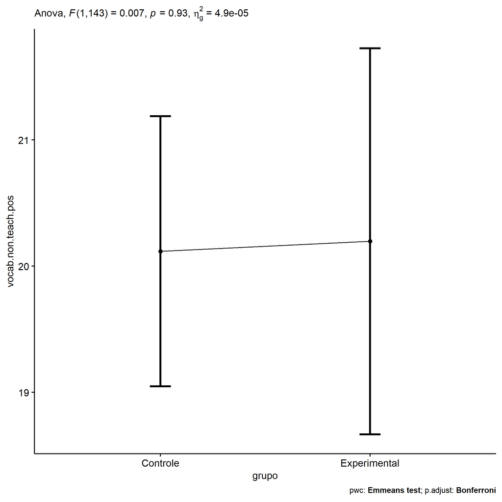

```r
if (!is.null(nrow(plots[["grupo"]]$data)))
  plots[["grupo"]] +
  if (ymin.ci < ymax.ci) ggplot2::ylim(ymin.ci, ymax.ci)
```

```r
plots <- oneWayAncovaBoxPlots(
  wdat, "vocab.non.teach.pos", "grupo", aov, pwc, covar = "vocab.non.teach.pre",
  theme = "classic", color = color[["grupo"]],
  subtitle = which(aov$Effect == "grupo"))
```

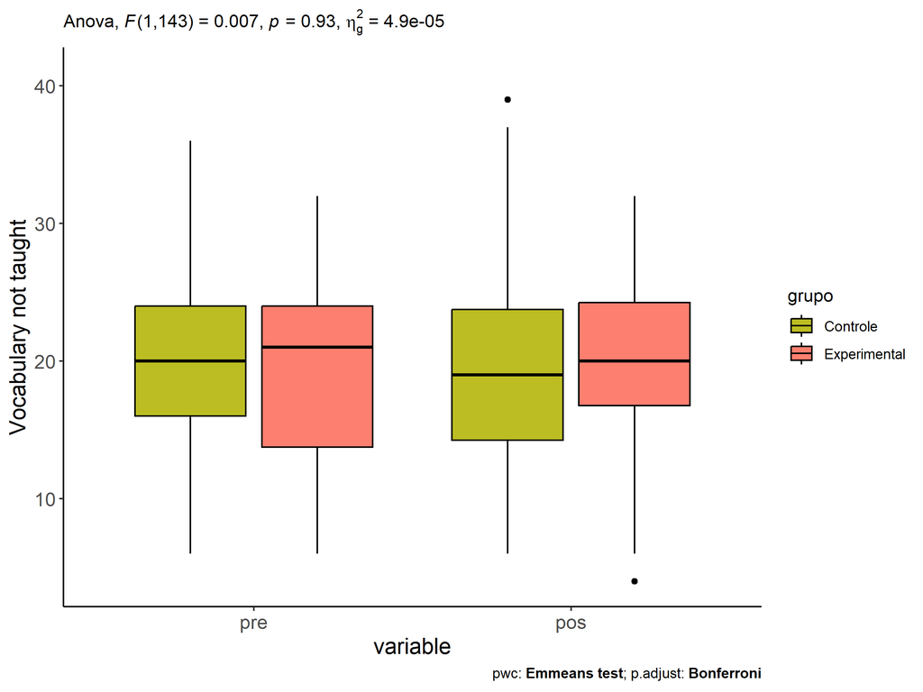

```r
if (length(unique(wdat[["grupo"]])) > 1)
  plots[["grupo"]] + ggplot2::ylab("Vocabulary not taught") +
  ggplot2::scale_x_discrete(labels=c('pre', 'pos')) +
  if (ymin < ymax) ggplot2::ylim(ymin, ymax)
```

```r
if (length(unique(wdat.long[["grupo"]])) > 1)
  plots <- oneWayAncovaBoxPlots(
    wdat.long, "vocab.non.teach", "grupo", aov, pwc.long,
    pre.post = "time", theme = "classic", color = color$prepost)
```

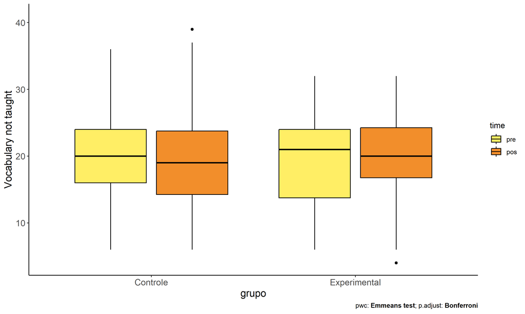

```r
if (length(unique(wdat.long[["grupo"]])) > 1)
  plots[["grupo"]] + ggplot2::ylab("Vocabulary not taught") +
  if (ymin < ymax) ggplot2::ylim(ymin, ymax)
```

### Checking linearity assumption

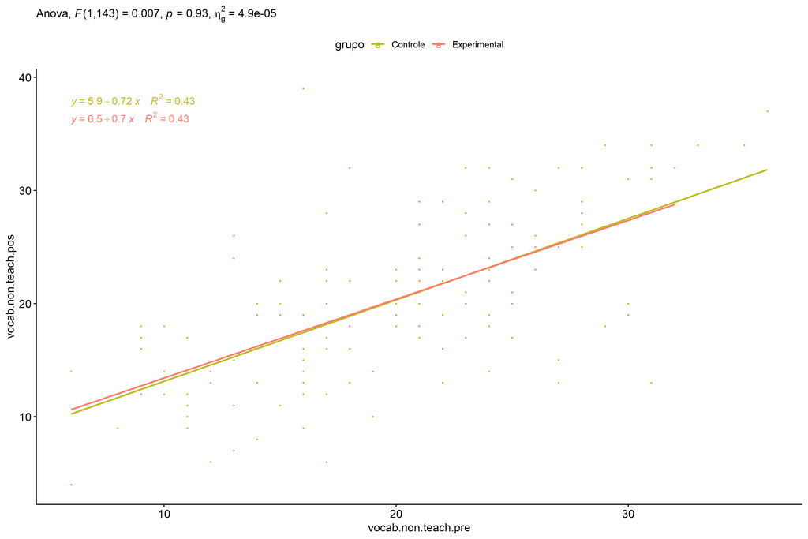

```r
ggscatter(wdat, x = "vocab.non.teach.pre", y = "vocab.non.teach.pos", size = 0.5,
          color = "grupo", add = "reg.line")+
  stat_regline_equation(
    aes(label =  paste(..eq.label.., ..rr.label.., sep = "~~~~"), color = grupo)
  ) +
  ggplot2::labs(subtitle = rstatix::get_test_label(aov, detailed = T, row = which(aov$Effect == "grupo"))) +
  ggplot2::scale_color_manual(values = color[["grupo"]]) +
  if (ymin < ymax) ggplot2::ylim(ymin, ymax)
```

### Checking normality and homogeneity

```r
res <- augment(lm(vocab.non.teach.pos ~ vocab.non.teach.pre + grupo, data = wdat))
```

```r
shapiro_test(res$.resid)
```

```
## # A tibble: 1 × 3
##   variable   statistic p.value
##   <chr>          <dbl>   <dbl>
## 1 res$.resid     0.984  0.0776
```

```r
levene_test(res, .resid ~ grupo)
```

```
## # A tibble: 1 × 4
##     df1   df2 statistic     p
##   <int> <int>     <dbl> <dbl>
## 1     1   144      1.39 0.240
```

# ANCOVA and Pairwise for two factors **grupo:Sexo**

## Without remove non-normal data

```r
pdat = remove_group_data(dat[!is.na(dat[["grupo"]]) & !is.na(dat[["Sexo"]]),],
                         "vocab.non.teach.pos", c("grupo","Sexo"))
pdat = pdat[pdat[["Sexo"]] %in% do.call(
  intersect, lapply(unique(pdat[["grupo"]]), FUN = function(x) {
    unique(pdat[["Sexo"]][which(pdat[["grupo"]] == x)])
  })),]
pdat[["grupo"]] = factor(pdat[["grupo"]], level[["grupo"]])
pdat[["Sexo"]] = factor(
  pdat[["Sexo"]],
  level[["Sexo"]][level[["Sexo"]] %in% unique(pdat[["Sexo"]])])

pdat.long <- rbind(pdat[,c("id","grupo","Sexo")], pdat[,c("id","grupo","Sexo")])
pdat.long[["time"]] <- c(rep("pre", nrow(pdat)), rep("pos", nrow(pdat)))
pdat.long[["time"]] <- factor(pdat.long[["time"]], c("pre","pos"))
pdat.long[["vocab.non.teach"]] <- c(pdat[["vocab.non.teach.pre"]], pdat[["vocab.non.teach.pos"]])

if (length(unique(pdat[["Sexo"]])) >= 2) {
  aov = anova_test(pdat, vocab.non.teach.pos ~ vocab.non.teach.pre + grupo*Sexo)
  laov[["grupo:Sexo"]] <- get_anova_table(aov)
}
```

```r
if (length(unique(pdat[["Sexo"]])) >= 2) {
  pwcs <- list()
  pwcs[["Sexo"]] <- emmeans_test(
    group_by(pdat, grupo), vocab.non.teach.pos ~ Sexo,
    covariate = vocab.non.teach.pre, p.adjust.method = "bonferroni")
  pwcs[["grupo"]] <- emmeans_test(
    group_by(pdat, Sexo), vocab.non.teach.pos ~ grupo,
    covariate = vocab.non.teach.pre, p.adjust.method = "bonferroni")

  pwc <- plyr::rbind.fill(pwcs[["grupo"]], pwcs[["Sexo"]])
  pwc <- pwc[,c("grupo","Sexo", colnames(pwc)[!colnames(pwc) %in% c("grupo","Sexo")])]
}
```

```r
if (length(unique(pdat[["Sexo"]])) >= 2) {
  pwc.long <- emmeans_test(dplyr::group_by_at(pdat.long, c("grupo","Sexo")),
                           vocab.non.teach ~ time,
                           p.adjust.method = "bonferroni")
  lpwc[["grupo:Sexo"]] <- plyr::rbind.fill(pwc, pwc.long)
}
```

```r
if (length(unique(pdat[["Sexo"]])) >= 2) {
  ds <- get.descriptives(pdat, "vocab.non.teach.pos", c("grupo","Sexo"), covar = "vocab.non.teach.pre")
  ds <- merge(ds[ds$variable != "vocab.non.teach.pre",],
              ds[ds$variable == "vocab.non.teach.pre", !colnames(ds) %in% c("variable")],
              by = c("grupo","Sexo"), all.x = T, suffixes = c("", ".vocab.non.teach.pre"))
  ds <- merge(get_emmeans(pwcs[["grupo"]]), ds,
              by = c("grupo","Sexo"), suffixes = c(".emms", ""))
  ds <- ds[,c("grupo","Sexo","n","mean.vocab.non.teach.pre","se.vocab.non.teach.pre","mean","se",
              "emmean","se.emms","conf.low","conf.high")]

  colnames(ds) <- c("grupo","Sexo", "N", paste0(c("M","SE")," (pre)"),
                    paste0(c("M","SE"), " (unadj)"),
                    paste0(c("M", "SE"), " (adj)"), "conf.low", "conf.high")

  lemms[["grupo:Sexo"]] <- ds
}
```

## Computing ANCOVA and PairWise After removing non-normal data (OK)

```r
if (length(unique(pdat[["Sexo"]])) >= 2) {
  wdat = pdat

  res = residuals(lm(vocab.non.teach.pos ~ vocab.non.teach.pre + grupo*Sexo, data = wdat))
  non.normal = getNonNormal(res, wdat$id, plimit = 0.05)

  wdat = wdat[!wdat$id %in% non.normal,]

  wdat.long <- rbind(wdat[,c("id","grupo","Sexo")], wdat[,c("id","grupo","Sexo")])
  wdat.long[["time"]] <- c(rep("pre", nrow(wdat)), rep("pos", nrow(wdat)))
  wdat.long[["time"]] <- factor(wdat.long[["time"]], c("pre","pos"))
  wdat.long[["vocab.non.teach"]] <- c(wdat[["vocab.non.teach.pre"]], wdat[["vocab.non.teach.pos"]])


  ldat[["grupo:Sexo"]] = wdat

  (non.normal)
}
```

```r
if (length(unique(pdat[["Sexo"]])) >= 2) {
  aov = anova_test(wdat, vocab.non.teach.pos ~ vocab.non.teach.pre + grupo*Sexo)
  laov[["grupo:Sexo"]] <- merge(get_anova_table(aov), laov[["grupo:Sexo"]],
                                         by="Effect", suffixes = c("","'"))
  df = get_anova_table(aov)
}
```

| Effect | DFn | DFd | F | p | p<.05 | ges |
| --- | --- | --- | --- | --- | --- | --- |
| vocab.non.teach.pre | 1 | 141 | 106.080 | 0.000 | * | 0.429 |
| grupo | 1 | 141 | 0.001 | 0.976 |  | 0.000 |
| Sexo | 1 | 141 | 0.278 | 0.599 |  | 0.002 |
| grupo:Sexo | 1 | 141 | 0.142 | 0.707 |  | 0.001 |

```r
if (length(unique(pdat[["Sexo"]])) >= 2) {
  pwcs <- list()
  pwcs[["Sexo"]] <- emmeans_test(
    group_by(wdat, grupo), vocab.non.teach.pos ~ Sexo,
    covariate = vocab.non.teach.pre, p.adjust.method = "bonferroni")
  pwcs[["grupo"]] <- emmeans_test(
    group_by(wdat, Sexo), vocab.non.teach.pos ~ grupo,
    covariate = vocab.non.teach.pre, p.adjust.method = "bonferroni")

  pwc <- plyr::rbind.fill(pwcs[["grupo"]], pwcs[["Sexo"]])
  pwc <- pwc[,c("grupo","Sexo", colnames(pwc)[!colnames(pwc) %in% c("grupo","Sexo")])]
}
```

| grupo | Sexo | term | .y. | group1 | group2 | df | statistic | p | p.adj | p.adj.signif |
| --- | --- | --- | --- | --- | --- | --- | --- | --- | --- | --- |
|  | F | vocab.non.teach.pre*grupo | vocab.non.teach.pos | Controle | Experimental | 141 | 0.282 | 0.779 | 0.779 | ns |
|  | M | vocab.non.teach.pre*grupo | vocab.non.teach.pos | Controle | Experimental | 141 | -0.252 | 0.801 | 0.801 | ns |
| Controle |  | vocab.non.teach.pre*Sexo | vocab.non.teach.pos | F | M | 141 | -0.231 | 0.818 | 0.818 | ns |
| Experimental |  | vocab.non.teach.pre*Sexo | vocab.non.teach.pos | F | M | 141 | -0.606 | 0.545 | 0.545 | ns |

```r
if (length(unique(pdat[["Sexo"]])) >= 2) {
  pwc.long <- emmeans_test(dplyr::group_by_at(wdat.long, c("grupo","Sexo")),
                           vocab.non.teach ~ time,
                           p.adjust.method = "bonferroni")
  lpwc[["grupo:Sexo"]] <- merge(plyr::rbind.fill(pwc, pwc.long),
                                         lpwc[["grupo:Sexo"]],
                                         by=c("grupo","Sexo","term",".y.","group1","group2"),
                                         suffixes = c("","'"))
}
```

| grupo | Sexo | term | .y. | group1 | group2 | df | statistic | p | p.adj | p.adj.signif |
| --- | --- | --- | --- | --- | --- | --- | --- | --- | --- | --- |
| Controle | F | time | vocab.non.teach | pre | pos | 284 | -0.063 | 0.950 | 0.950 | ns |
| Controle | M | time | vocab.non.teach | pre | pos | 284 | -0.434 | 0.665 | 0.665 | ns |
| Experimental | F | time | vocab.non.teach | pre | pos | 284 | 0.078 | 0.938 | 0.938 | ns |
| Experimental | M | time | vocab.non.teach | pre | pos | 284 | -0.587 | 0.558 | 0.558 | ns |

```r
if (length(unique(pdat[["Sexo"]])) >= 2) {
  ds <- get.descriptives(wdat, "vocab.non.teach.pos", c("grupo","Sexo"), covar = "vocab.non.teach.pre")
  ds <- merge(ds[ds$variable != "vocab.non.teach.pre",],
              ds[ds$variable == "vocab.non.teach.pre", !colnames(ds) %in% c("variable")],
              by = c("grupo","Sexo"), all.x = T, suffixes = c("", ".vocab.non.teach.pre"))
  ds <- merge(get_emmeans(pwcs[["grupo"]]), ds,
              by = c("grupo","Sexo"), suffixes = c(".emms", ""))
  ds <- ds[,c("grupo","Sexo","n","mean.vocab.non.teach.pre","se.vocab.non.teach.pre",
              "mean","se","emmean","se.emms","conf.low","conf.high")]

  colnames(ds) <- c("grupo","Sexo", "N", paste0(c("M","SE")," (pre)"),
                    paste0(c("M","SE"), " (unadj)"),
                    paste0(c("M", "SE"), " (adj)"), "conf.low", "conf.high")

  lemms[["grupo:Sexo"]] <- merge(ds, lemms[["grupo:Sexo"]],
                                          by=c("grupo","Sexo"), suffixes = c("","'"))
}
```

| grupo | Sexo | N | M (pre) | SE (pre) | M (unadj) | SE (unadj) | M (adj) | SE (adj) | conf.low | conf.high |
| --- | --- | --- | --- | --- | --- | --- | --- | --- | --- | --- |
| Controle | F | 43 | 20.326 | 0.932 | 20.419 | 0.898 | 19.975 | 0.823 | 18.349 | 21.602 |
| Controle | M | 55 | 19.564 | 0.949 | 20.127 | 1.119 | 20.229 | 0.727 | 18.792 | 21.665 |
| Experimental | F | 16 | 19.750 | 1.551 | 19.562 | 1.201 | 19.531 | 1.347 | 16.868 | 22.193 |
| Experimental | M | 32 | 19.094 | 1.100 | 20.094 | 1.289 | 20.531 | 0.953 | 18.647 | 22.416 |

### Plots for ancova

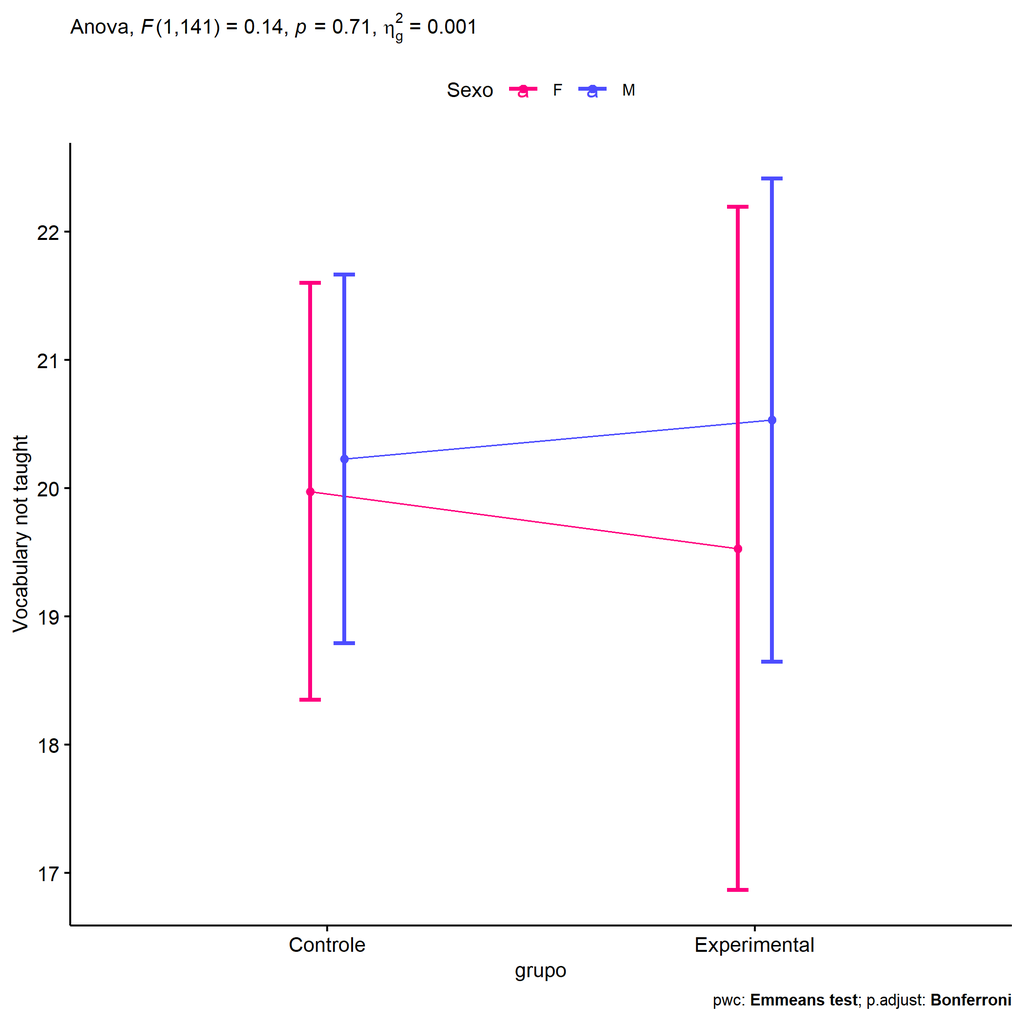

```r
if (length(unique(pdat[["Sexo"]])) >= 2) {
  ggPlotAoC2(pwcs, "grupo", "Sexo", aov, ylab = "Vocabulary not taught",
             subtitle = which(aov$Effect == "grupo:Sexo"), addParam = "errorbar") +
    ggplot2::scale_color_manual(values = color[["Sexo"]]) +
    if (ymin.ci < ymax.ci) ggplot2::ylim(ymin.ci, ymax.ci)
}
```

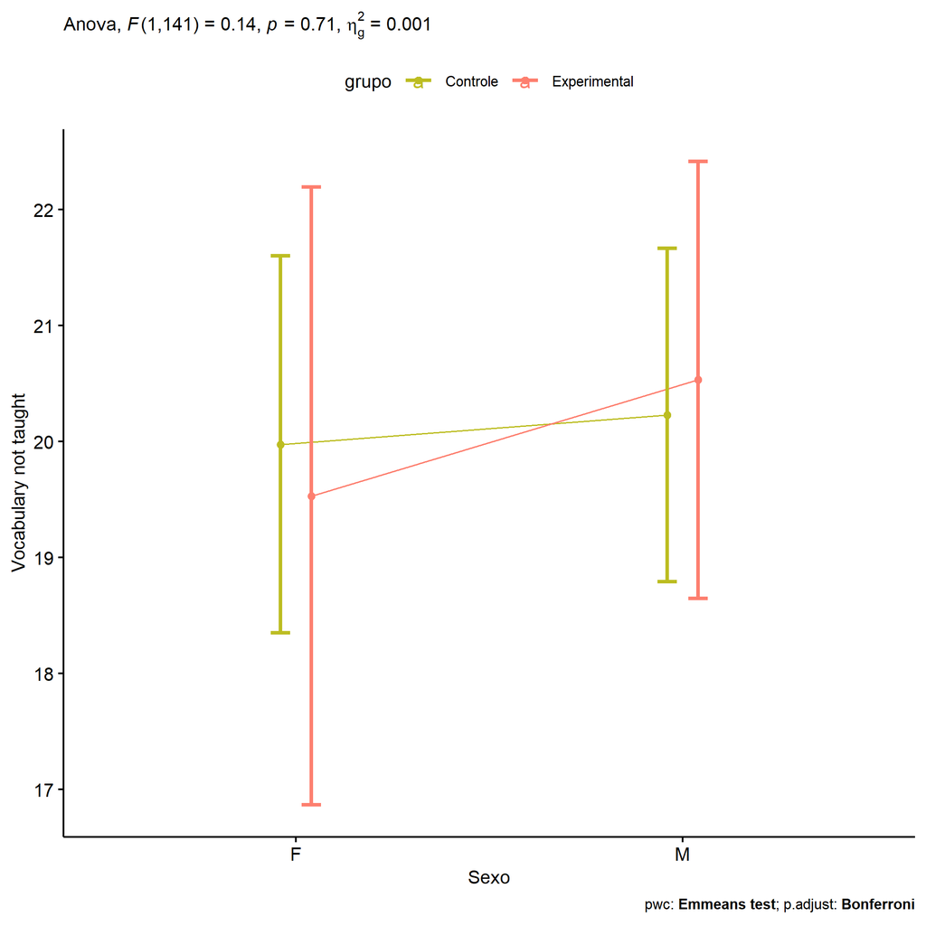

```r
if (length(unique(pdat[["Sexo"]])) >= 2) {
  ggPlotAoC2(pwcs, "Sexo", "grupo", aov, ylab = "Vocabulary not taught",
               subtitle = which(aov$Effect == "grupo:Sexo"), addParam = "errorbar") +
      ggplot2::scale_color_manual(values = color[["grupo"]]) +
      if (ymin.ci < ymax.ci) ggplot2::ylim(ymin.ci, ymax.ci)
}
```

```r
if (length(unique(pdat[["Sexo"]])) >= 2) {
  plots <- twoWayAncovaBoxPlots(
    wdat, "vocab.non.teach.pos", c("grupo","Sexo"), aov, pwcs, covar = "vocab.non.teach.pre",
    theme = "classic", color = color[["grupo:Sexo"]],
    subtitle = which(aov$Effect == "grupo:Sexo"))
}
```

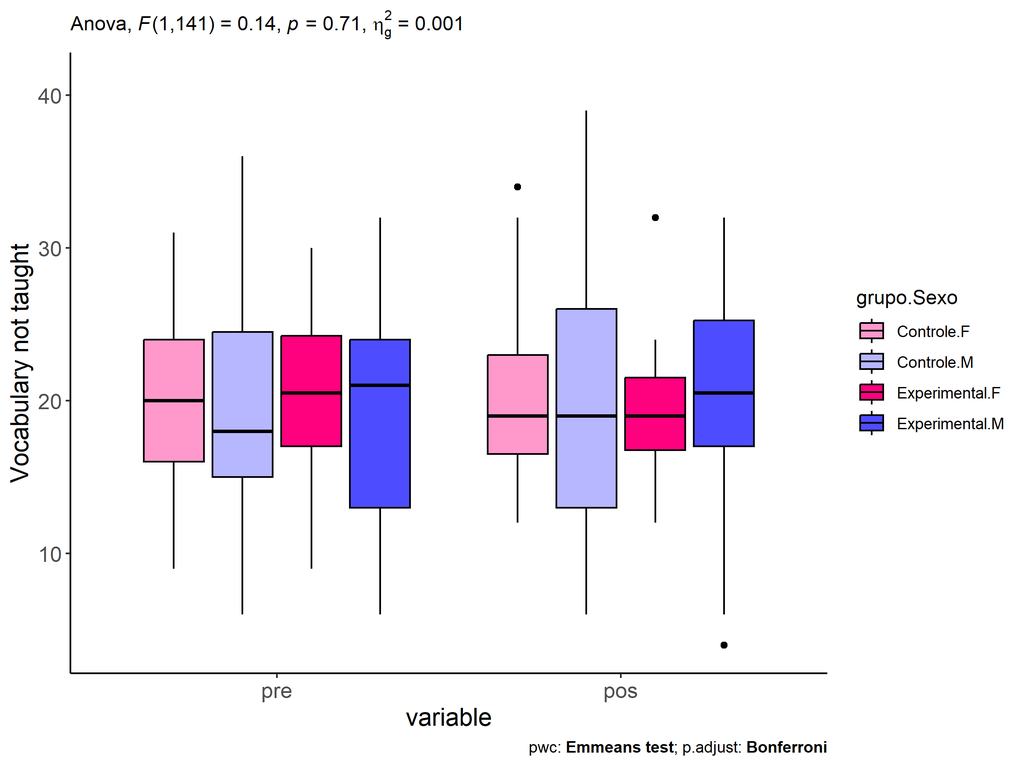

```r
if (length(unique(pdat[["Sexo"]])) >= 2) {
  plots[["grupo:Sexo"]] + ggplot2::ylab("Vocabulary not taught") +
  ggplot2::scale_x_discrete(labels=c('pre', 'pos')) +
  if (ymin < ymax) ggplot2::ylim(ymin, ymax)
}
```

```r
if (length(unique(pdat[["Sexo"]])) >= 2) {
  plots <- twoWayAncovaBoxPlots(
    wdat.long, "vocab.non.teach", c("grupo","Sexo"), aov, pwc.long,
    pre.post = "time",
    theme = "classic", color = color$prepost)
}
```

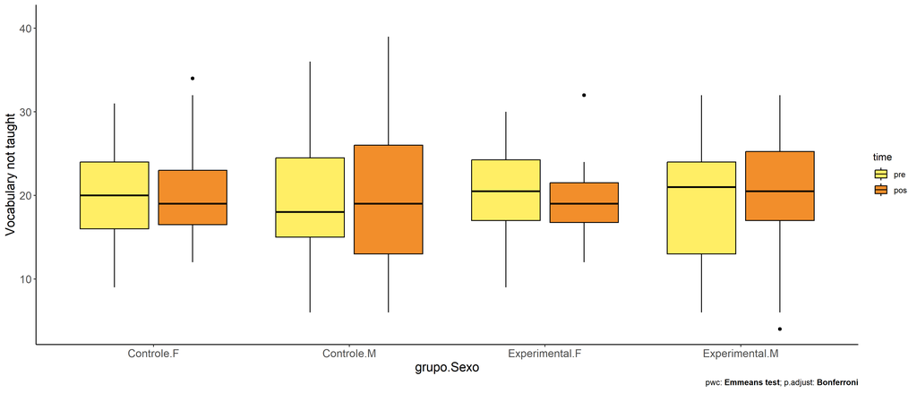

```r
if (length(unique(pdat[["Sexo"]])) >= 2)
  plots[["grupo:Sexo"]] + ggplot2::ylab("Vocabulary not taught") +
    if (ymin < ymax) ggplot2::ylim(ymin, ymax)
```

### Checking linearity assumption

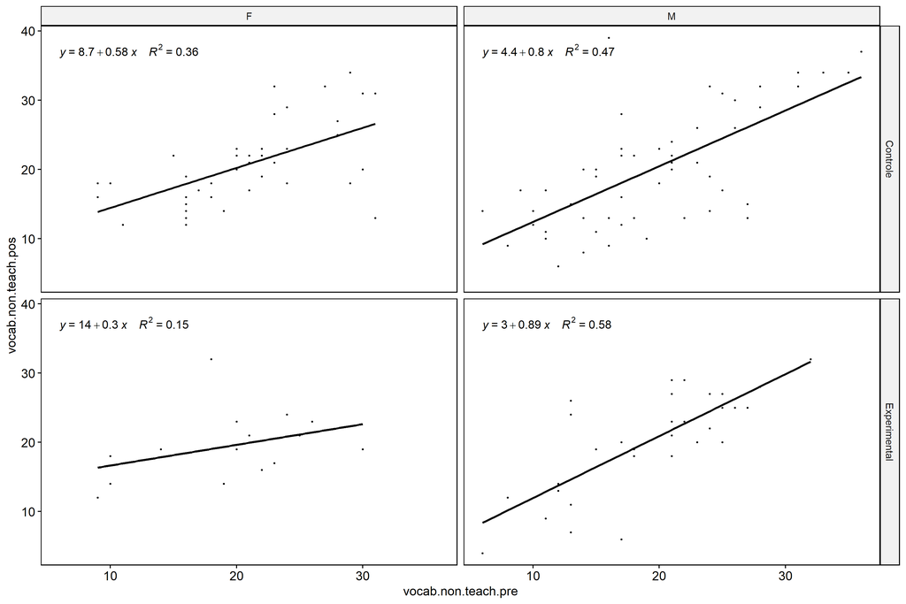

```r
if (length(unique(pdat[["Sexo"]])) >= 2) {
  ggscatter(wdat, x = "vocab.non.teach.pre", y = "vocab.non.teach.pos", size = 0.5,
            facet.by = c("grupo","Sexo"), add = "reg.line")+
    stat_regline_equation(
      aes(label =  paste(..eq.label.., ..rr.label.., sep = "~~~~"))
    ) +
    if (ymin < ymax) ggplot2::ylim(ymin, ymax)
}
```

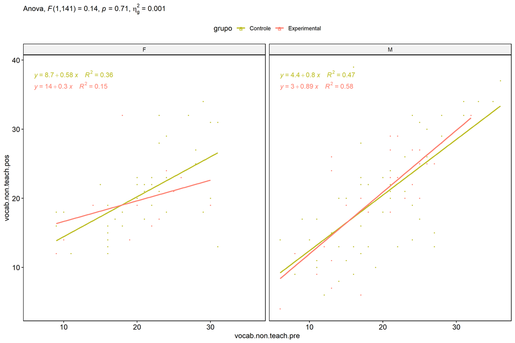

```r
if (length(unique(pdat[["Sexo"]])) >= 2) {
  ggscatter(wdat, x = "vocab.non.teach.pre", y = "vocab.non.teach.pos", size = 0.5,
            color = "grupo", facet.by = "Sexo", add = "reg.line")+
    stat_regline_equation(
      aes(label =  paste(..eq.label.., ..rr.label.., sep = "~~~~"), color = grupo)
    ) +
    ggplot2::labs(subtitle = rstatix::get_test_label(aov, detailed = T, row = which(aov$Effect == "grupo:Sexo"))) +
    ggplot2::scale_color_manual(values = color[["grupo"]]) +
    if (ymin < ymax) ggplot2::ylim(ymin, ymax)
}
```

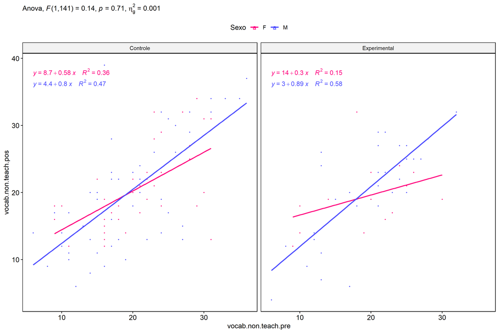

```r
if (length(unique(pdat[["Sexo"]])) >= 2) {
  ggscatter(wdat, x = "vocab.non.teach.pre", y = "vocab.non.teach.pos", size = 0.5,
            color = "Sexo", facet.by = "grupo", add = "reg.line")+
    stat_regline_equation(
      aes(label =  paste(..eq.label.., ..rr.label.., sep = "~~~~"), color = Sexo)
    ) +
    ggplot2::labs(subtitle = rstatix::get_test_label(aov, detailed = T, row = which(aov$Effect == "grupo:Sexo"))) +
    ggplot2::scale_color_manual(values = color[["Sexo"]]) +
    if (ymin < ymax) ggplot2::ylim(ymin, ymax)
}
```

### Checking normality and homogeneity

```r
if (length(unique(pdat[["Sexo"]])) >= 2)
  res <- augment(lm(vocab.non.teach.pos ~ vocab.non.teach.pre + grupo*Sexo, data = wdat))
```

```r
if (length(unique(pdat[["Sexo"]])) >= 2)
  shapiro_test(res$.resid)
```

```
## # A tibble: 1 × 3
##   variable   statistic p.value
##   <chr>          <dbl>   <dbl>
## 1 res$.resid     0.983  0.0615
```

```r
if (length(unique(pdat[["Sexo"]])) >= 2)
  levene_test(res, .resid ~ grupo*Sexo)
```

```
## # A tibble: 1 × 4
##     df1   df2 statistic     p
##   <int> <int>     <dbl> <dbl>
## 1     3   142      1.19 0.317
```

# ANCOVA and Pairwise for two factors **grupo:Zona**

## Without remove non-normal data

```r
pdat = remove_group_data(dat[!is.na(dat[["grupo"]]) & !is.na(dat[["Zona"]]),],
                         "vocab.non.teach.pos", c("grupo","Zona"))
pdat = pdat[pdat[["Zona"]] %in% do.call(
  intersect, lapply(unique(pdat[["grupo"]]), FUN = function(x) {
    unique(pdat[["Zona"]][which(pdat[["grupo"]] == x)])
  })),]
pdat[["grupo"]] = factor(pdat[["grupo"]], level[["grupo"]])
pdat[["Zona"]] = factor(
  pdat[["Zona"]],
  level[["Zona"]][level[["Zona"]] %in% unique(pdat[["Zona"]])])

pdat.long <- rbind(pdat[,c("id","grupo","Zona")], pdat[,c("id","grupo","Zona")])
pdat.long[["time"]] <- c(rep("pre", nrow(pdat)), rep("pos", nrow(pdat)))
pdat.long[["time"]] <- factor(pdat.long[["time"]], c("pre","pos"))
pdat.long[["vocab.non.teach"]] <- c(pdat[["vocab.non.teach.pre"]], pdat[["vocab.non.teach.pos"]])

if (length(unique(pdat[["Zona"]])) >= 2) {
  aov = anova_test(pdat, vocab.non.teach.pos ~ vocab.non.teach.pre + grupo*Zona)
  laov[["grupo:Zona"]] <- get_anova_table(aov)
}
```

```r
if (length(unique(pdat[["Zona"]])) >= 2) {
  pwcs <- list()
  pwcs[["Zona"]] <- emmeans_test(
    group_by(pdat, grupo), vocab.non.teach.pos ~ Zona,
    covariate = vocab.non.teach.pre, p.adjust.method = "bonferroni")
  pwcs[["grupo"]] <- emmeans_test(
    group_by(pdat, Zona), vocab.non.teach.pos ~ grupo,
    covariate = vocab.non.teach.pre, p.adjust.method = "bonferroni")

  pwc <- plyr::rbind.fill(pwcs[["grupo"]], pwcs[["Zona"]])
  pwc <- pwc[,c("grupo","Zona", colnames(pwc)[!colnames(pwc) %in% c("grupo","Zona")])]
}
```

```r
if (length(unique(pdat[["Zona"]])) >= 2) {
  pwc.long <- emmeans_test(dplyr::group_by_at(pdat.long, c("grupo","Zona")),
                           vocab.non.teach ~ time,
                           p.adjust.method = "bonferroni")
  lpwc[["grupo:Zona"]] <- plyr::rbind.fill(pwc, pwc.long)
}
```

```r
if (length(unique(pdat[["Zona"]])) >= 2) {
  ds <- get.descriptives(pdat, "vocab.non.teach.pos", c("grupo","Zona"), covar = "vocab.non.teach.pre")
  ds <- merge(ds[ds$variable != "vocab.non.teach.pre",],
              ds[ds$variable == "vocab.non.teach.pre", !colnames(ds) %in% c("variable")],
              by = c("grupo","Zona"), all.x = T, suffixes = c("", ".vocab.non.teach.pre"))
  ds <- merge(get_emmeans(pwcs[["grupo"]]), ds,
              by = c("grupo","Zona"), suffixes = c(".emms", ""))
  ds <- ds[,c("grupo","Zona","n","mean.vocab.non.teach.pre","se.vocab.non.teach.pre","mean","se",
              "emmean","se.emms","conf.low","conf.high")]

  colnames(ds) <- c("grupo","Zona", "N", paste0(c("M","SE")," (pre)"),
                    paste0(c("M","SE"), " (unadj)"),
                    paste0(c("M", "SE"), " (adj)"), "conf.low", "conf.high")

  lemms[["grupo:Zona"]] <- ds
}
```

## Computing ANCOVA and PairWise After removing non-normal data (OK)

```r
if (length(unique(pdat[["Zona"]])) >= 2) {
  wdat = pdat

  res = residuals(lm(vocab.non.teach.pos ~ vocab.non.teach.pre + grupo*Zona, data = wdat))
  non.normal = getNonNormal(res, wdat$id, plimit = 0.05)

  wdat = wdat[!wdat$id %in% non.normal,]

  wdat.long <- rbind(wdat[,c("id","grupo","Zona")], wdat[,c("id","grupo","Zona")])
  wdat.long[["time"]] <- c(rep("pre", nrow(wdat)), rep("pos", nrow(wdat)))
  wdat.long[["time"]] <- factor(wdat.long[["time"]], c("pre","pos"))
  wdat.long[["vocab.non.teach"]] <- c(wdat[["vocab.non.teach.pre"]], wdat[["vocab.non.teach.pos"]])


  ldat[["grupo:Zona"]] = wdat

  (non.normal)
}
```

```
## [1] "P3569"
```

```r
if (length(unique(pdat[["Zona"]])) >= 2) {
  aov = anova_test(wdat, vocab.non.teach.pos ~ vocab.non.teach.pre + grupo*Zona)
  laov[["grupo:Zona"]] <- merge(get_anova_table(aov), laov[["grupo:Zona"]],
                                         by="Effect", suffixes = c("","'"))
  df = get_anova_table(aov)
}
```

| Effect | DFn | DFd | F | p | p<.05 | ges |
| --- | --- | --- | --- | --- | --- | --- |
| vocab.non.teach.pre | 1 | 100 | 142.072 | 0.000 | * | 0.587 |
| grupo | 1 | 100 | 0.002 | 0.969 |  | 0.000 |
| Zona | 1 | 100 | 1.087 | 0.300 |  | 0.011 |
| grupo:Zona | 1 | 100 | 0.632 | 0.429 |  | 0.006 |

```r
if (length(unique(pdat[["Zona"]])) >= 2) {
  pwcs <- list()
  pwcs[["Zona"]] <- emmeans_test(
    group_by(wdat, grupo), vocab.non.teach.pos ~ Zona,
    covariate = vocab.non.teach.pre, p.adjust.method = "bonferroni")
  pwcs[["grupo"]] <- emmeans_test(
    group_by(wdat, Zona), vocab.non.teach.pos ~ grupo,
    covariate = vocab.non.teach.pre, p.adjust.method = "bonferroni")

  pwc <- plyr::rbind.fill(pwcs[["grupo"]], pwcs[["Zona"]])
  pwc <- pwc[,c("grupo","Zona", colnames(pwc)[!colnames(pwc) %in% c("grupo","Zona")])]
}
```

| grupo | Zona | term | .y. | group1 | group2 | df | statistic | p | p.adj | p.adj.signif |
| --- | --- | --- | --- | --- | --- | --- | --- | --- | --- | --- |
|  | Rural | vocab.non.teach.pre*grupo | vocab.non.teach.pos | Controle | Experimental | 100 | -0.338 | 0.736 | 0.736 | ns |
|  | Urbana | vocab.non.teach.pre*grupo | vocab.non.teach.pos | Controle | Experimental | 100 | 0.723 | 0.471 | 0.471 | ns |
| Controle |  | vocab.non.teach.pre*Zona | vocab.non.teach.pos | Rural | Urbana | 100 | 0.402 | 0.689 | 0.689 | ns |
| Experimental |  | vocab.non.teach.pre*Zona | vocab.non.teach.pos | Rural | Urbana | 100 | 1.244 | 0.216 | 0.216 | ns |

```r
if (length(unique(pdat[["Zona"]])) >= 2) {
  pwc.long <- emmeans_test(dplyr::group_by_at(wdat.long, c("grupo","Zona")),
                           vocab.non.teach ~ time,
                           p.adjust.method = "bonferroni")
  lpwc[["grupo:Zona"]] <- merge(plyr::rbind.fill(pwc, pwc.long),
                                         lpwc[["grupo:Zona"]],
                                         by=c("grupo","Zona","term",".y.","group1","group2"),
                                         suffixes = c("","'"))
}
```

| grupo | Zona | term | .y. | group1 | group2 | df | statistic | p | p.adj | p.adj.signif |
| --- | --- | --- | --- | --- | --- | --- | --- | --- | --- | --- |
| Controle | Rural | time | vocab.non.teach | pre | pos | 202 | -0.182 | 0.856 | 0.856 | ns |
| Controle | Urbana | time | vocab.non.teach | pre | pos | 202 | 0.031 | 0.975 | 0.975 | ns |
| Experimental | Rural | time | vocab.non.teach | pre | pos | 202 | -0.446 | 0.656 | 0.656 | ns |
| Experimental | Urbana | time | vocab.non.teach | pre | pos | 202 | 0.604 | 0.546 | 0.546 | ns |

```r
if (length(unique(pdat[["Zona"]])) >= 2) {
  ds <- get.descriptives(wdat, "vocab.non.teach.pos", c("grupo","Zona"), covar = "vocab.non.teach.pre")
  ds <- merge(ds[ds$variable != "vocab.non.teach.pre",],
              ds[ds$variable == "vocab.non.teach.pre", !colnames(ds) %in% c("variable")],
              by = c("grupo","Zona"), all.x = T, suffixes = c("", ".vocab.non.teach.pre"))
  ds <- merge(get_emmeans(pwcs[["grupo"]]), ds,
              by = c("grupo","Zona"), suffixes = c(".emms", ""))
  ds <- ds[,c("grupo","Zona","n","mean.vocab.non.teach.pre","se.vocab.non.teach.pre",
              "mean","se","emmean","se.emms","conf.low","conf.high")]

  colnames(ds) <- c("grupo","Zona", "N", paste0(c("M","SE")," (pre)"),
                    paste0(c("M","SE"), " (unadj)"),
                    paste0(c("M", "SE"), " (adj)"), "conf.low", "conf.high")

  lemms[["grupo:Zona"]] <- merge(ds, lemms[["grupo:Zona"]],
                                          by=c("grupo","Zona"), suffixes = c("","'"))
}
```

| grupo | Zona | N | M (pre) | SE (pre) | M (unadj) | SE (unadj) | M (adj) | SE (adj) | conf.low | conf.high |
| --- | --- | --- | --- | --- | --- | --- | --- | --- | --- | --- |
| Controle | Rural | 55 | 19.836 | 0.839 | 20.073 | 0.971 | 19.774 | 0.616 | 18.551 | 20.996 |
| Controle | Urbana | 11 | 18.182 | 2.522 | 18.091 | 2.168 | 19.166 | 1.380 | 16.428 | 21.903 |
| Experimental | Rural | 34 | 18.882 | 1.078 | 19.618 | 1.192 | 20.111 | 0.784 | 18.555 | 21.667 |
| Experimental | Urbana | 5 | 22.400 | 3.187 | 19.800 | 2.634 | 17.372 | 2.052 | 13.300 | 21.444 |

### Plots for ancova

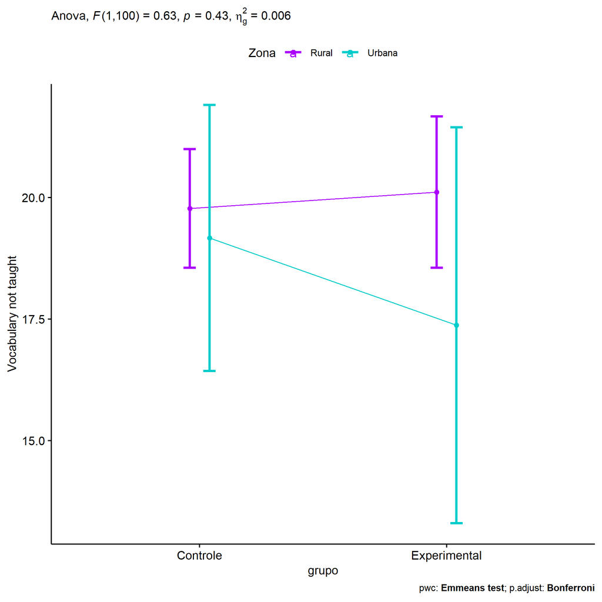

```r
if (length(unique(pdat[["Zona"]])) >= 2) {
  ggPlotAoC2(pwcs, "grupo", "Zona", aov, ylab = "Vocabulary not taught",
             subtitle = which(aov$Effect == "grupo:Zona"), addParam = "errorbar") +
    ggplot2::scale_color_manual(values = color[["Zona"]]) +
    if (ymin.ci < ymax.ci) ggplot2::ylim(ymin.ci, ymax.ci)
}
```

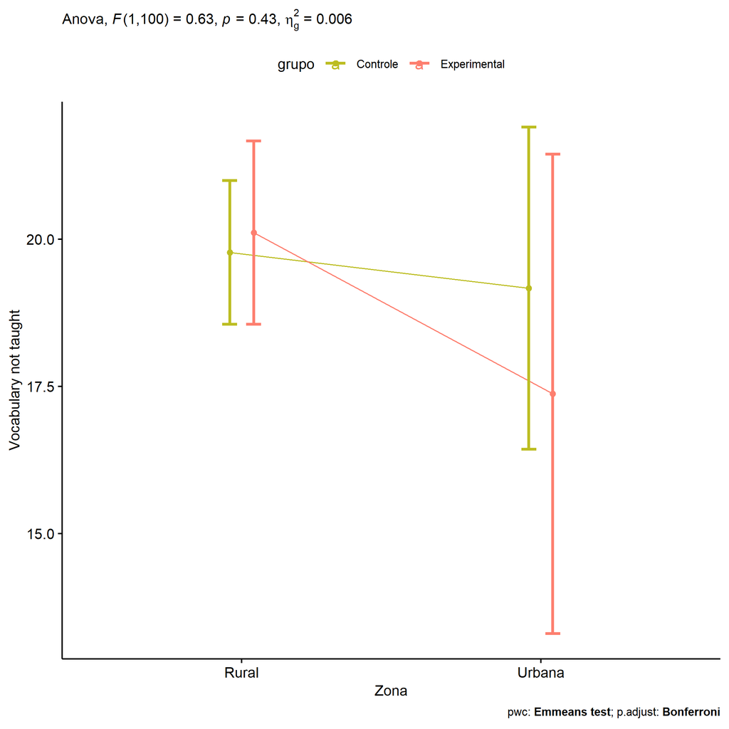

```r
if (length(unique(pdat[["Zona"]])) >= 2) {
  ggPlotAoC2(pwcs, "Zona", "grupo", aov, ylab = "Vocabulary not taught",
               subtitle = which(aov$Effect == "grupo:Zona"), addParam = "errorbar") +
      ggplot2::scale_color_manual(values = color[["grupo"]]) +
      if (ymin.ci < ymax.ci) ggplot2::ylim(ymin.ci, ymax.ci)
}
```

```r
if (length(unique(pdat[["Zona"]])) >= 2) {
  plots <- twoWayAncovaBoxPlots(
    wdat, "vocab.non.teach.pos", c("grupo","Zona"), aov, pwcs, covar = "vocab.non.teach.pre",
    theme = "classic", color = color[["grupo:Zona"]],
    subtitle = which(aov$Effect == "grupo:Zona"))
}
```

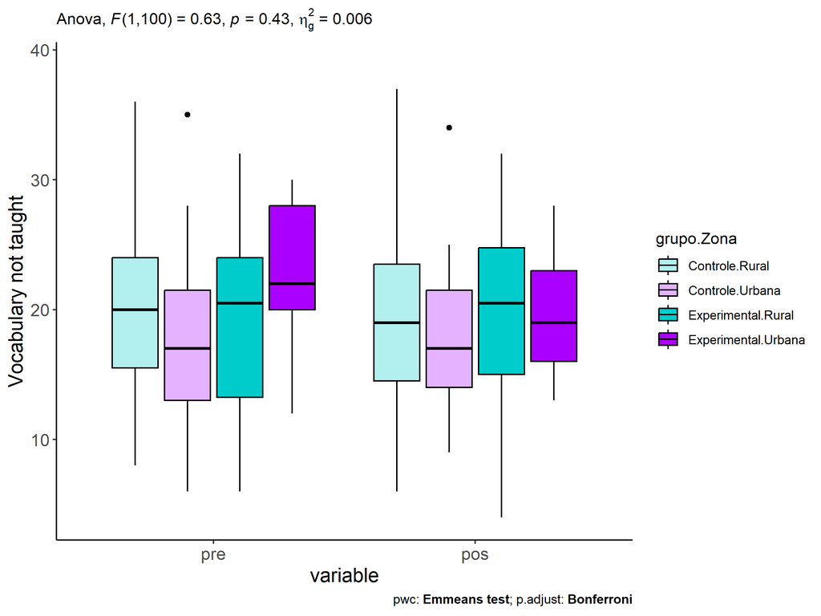

```r
if (length(unique(pdat[["Zona"]])) >= 2) {
  plots[["grupo:Zona"]] + ggplot2::ylab("Vocabulary not taught") +
  ggplot2::scale_x_discrete(labels=c('pre', 'pos')) +
  if (ymin < ymax) ggplot2::ylim(ymin, ymax)
}
```

```r
if (length(unique(pdat[["Zona"]])) >= 2) {
  plots <- twoWayAncovaBoxPlots(
    wdat.long, "vocab.non.teach", c("grupo","Zona"), aov, pwc.long,
    pre.post = "time",
    theme = "classic", color = color$prepost)
}
```

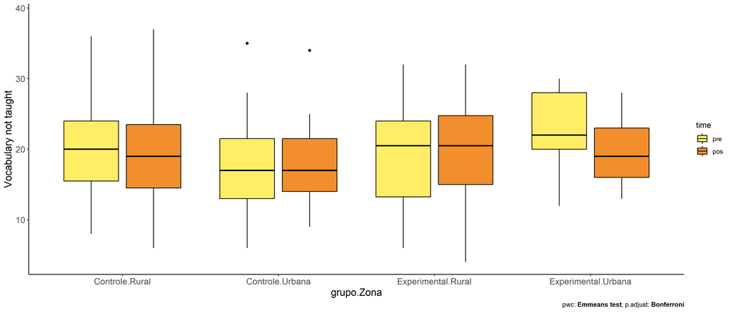

```r
if (length(unique(pdat[["Zona"]])) >= 2)
  plots[["grupo:Zona"]] + ggplot2::ylab("Vocabulary not taught") +
    if (ymin < ymax) ggplot2::ylim(ymin, ymax)
```

### Checking linearity assumption

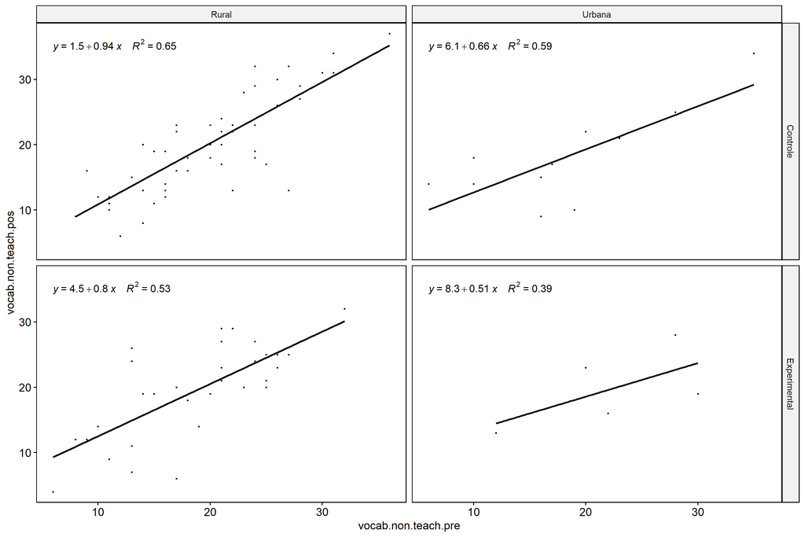

```r
if (length(unique(pdat[["Zona"]])) >= 2) {
  ggscatter(wdat, x = "vocab.non.teach.pre", y = "vocab.non.teach.pos", size = 0.5,
            facet.by = c("grupo","Zona"), add = "reg.line")+
    stat_regline_equation(
      aes(label =  paste(..eq.label.., ..rr.label.., sep = "~~~~"))
    ) +
    if (ymin < ymax) ggplot2::ylim(ymin, ymax)
}
```

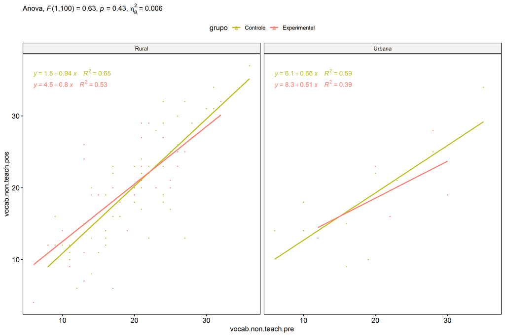

```r
if (length(unique(pdat[["Zona"]])) >= 2) {
  ggscatter(wdat, x = "vocab.non.teach.pre", y = "vocab.non.teach.pos", size = 0.5,
            color = "grupo", facet.by = "Zona", add = "reg.line")+
    stat_regline_equation(
      aes(label =  paste(..eq.label.., ..rr.label.., sep = "~~~~"), color = grupo)
    ) +
    ggplot2::labs(subtitle = rstatix::get_test_label(aov, detailed = T, row = which(aov$Effect == "grupo:Zona"))) +
    ggplot2::scale_color_manual(values = color[["grupo"]]) +
    if (ymin < ymax) ggplot2::ylim(ymin, ymax)
}
```

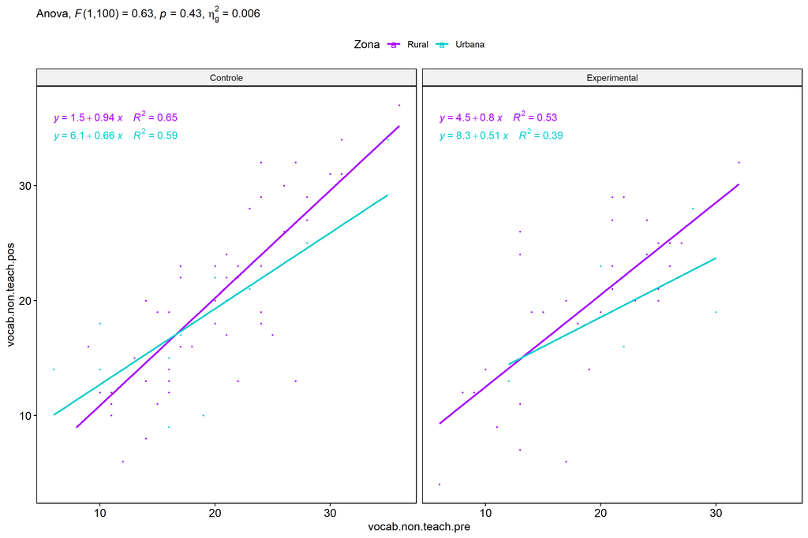

```r
if (length(unique(pdat[["Zona"]])) >= 2) {
  ggscatter(wdat, x = "vocab.non.teach.pre", y = "vocab.non.teach.pos", size = 0.5,
            color = "Zona", facet.by = "grupo", add = "reg.line")+
    stat_regline_equation(
      aes(label =  paste(..eq.label.., ..rr.label.., sep = "~~~~"), color = Zona)
    ) +
    ggplot2::labs(subtitle = rstatix::get_test_label(aov, detailed = T, row = which(aov$Effect == "grupo:Zona"))) +
    ggplot2::scale_color_manual(values = color[["Zona"]]) +
    if (ymin < ymax) ggplot2::ylim(ymin, ymax)
}
```

### Checking normality and homogeneity

```r
if (length(unique(pdat[["Zona"]])) >= 2)
  res <- augment(lm(vocab.non.teach.pos ~ vocab.non.teach.pre + grupo*Zona, data = wdat))
```

```r
if (length(unique(pdat[["Zona"]])) >= 2)
  shapiro_test(res$.resid)
```

```
## # A tibble: 1 × 3
##   variable   statistic p.value
##   <chr>          <dbl>   <dbl>
## 1 res$.resid     0.990   0.618
```

```r
if (length(unique(pdat[["Zona"]])) >= 2)
  levene_test(res, .resid ~ grupo*Zona)
```

```
## # A tibble: 1 × 4
##     df1   df2 statistic     p
##   <int> <int>     <dbl> <dbl>
## 1     3   101    0.0945 0.963
```

# ANCOVA and Pairwise for two factors **grupo:Cor.Raca**

## Without remove non-normal data

```r
pdat = remove_group_data(dat[!is.na(dat[["grupo"]]) & !is.na(dat[["Cor.Raca"]]),],
                         "vocab.non.teach.pos", c("grupo","Cor.Raca"))
pdat = pdat[pdat[["Cor.Raca"]] %in% do.call(
  intersect, lapply(unique(pdat[["grupo"]]), FUN = function(x) {
    unique(pdat[["Cor.Raca"]][which(pdat[["grupo"]] == x)])
  })),]
pdat[["grupo"]] = factor(pdat[["grupo"]], level[["grupo"]])
pdat[["Cor.Raca"]] = factor(
  pdat[["Cor.Raca"]],
  level[["Cor.Raca"]][level[["Cor.Raca"]] %in% unique(pdat[["Cor.Raca"]])])

pdat.long <- rbind(pdat[,c("id","grupo","Cor.Raca")], pdat[,c("id","grupo","Cor.Raca")])
pdat.long[["time"]] <- c(rep("pre", nrow(pdat)), rep("pos", nrow(pdat)))
pdat.long[["time"]] <- factor(pdat.long[["time"]], c("pre","pos"))
pdat.long[["vocab.non.teach"]] <- c(pdat[["vocab.non.teach.pre"]], pdat[["vocab.non.teach.pos"]])

if (length(unique(pdat[["Cor.Raca"]])) >= 2) {
  aov = anova_test(pdat, vocab.non.teach.pos ~ vocab.non.teach.pre + grupo*Cor.Raca)
  laov[["grupo:Cor.Raca"]] <- get_anova_table(aov)
}
```

```r
if (length(unique(pdat[["Cor.Raca"]])) >= 2) {
  pwcs <- list()
  pwcs[["Cor.Raca"]] <- emmeans_test(
    group_by(pdat, grupo), vocab.non.teach.pos ~ Cor.Raca,
    covariate = vocab.non.teach.pre, p.adjust.method = "bonferroni")
  pwcs[["grupo"]] <- emmeans_test(
    group_by(pdat, Cor.Raca), vocab.non.teach.pos ~ grupo,
    covariate = vocab.non.teach.pre, p.adjust.method = "bonferroni")

  pwc <- plyr::rbind.fill(pwcs[["grupo"]], pwcs[["Cor.Raca"]])
  pwc <- pwc[,c("grupo","Cor.Raca", colnames(pwc)[!colnames(pwc) %in% c("grupo","Cor.Raca")])]
}
```

```r
if (length(unique(pdat[["Cor.Raca"]])) >= 2) {
  pwc.long <- emmeans_test(dplyr::group_by_at(pdat.long, c("grupo","Cor.Raca")),
                           vocab.non.teach ~ time,
                           p.adjust.method = "bonferroni")
  lpwc[["grupo:Cor.Raca"]] <- plyr::rbind.fill(pwc, pwc.long)
}
```

```r
if (length(unique(pdat[["Cor.Raca"]])) >= 2) {
  ds <- get.descriptives(pdat, "vocab.non.teach.pos", c("grupo","Cor.Raca"), covar = "vocab.non.teach.pre")
  ds <- merge(ds[ds$variable != "vocab.non.teach.pre",],
              ds[ds$variable == "vocab.non.teach.pre", !colnames(ds) %in% c("variable")],
              by = c("grupo","Cor.Raca"), all.x = T, suffixes = c("", ".vocab.non.teach.pre"))
  ds <- merge(get_emmeans(pwcs[["grupo"]]), ds,
              by = c("grupo","Cor.Raca"), suffixes = c(".emms", ""))
  ds <- ds[,c("grupo","Cor.Raca","n","mean.vocab.non.teach.pre","se.vocab.non.teach.pre","mean","se",
              "emmean","se.emms","conf.low","conf.high")]

  colnames(ds) <- c("grupo","Cor.Raca", "N", paste0(c("M","SE")," (pre)"),
                    paste0(c("M","SE"), " (unadj)"),
                    paste0(c("M", "SE"), " (adj)"), "conf.low", "conf.high")

  lemms[["grupo:Cor.Raca"]] <- ds
}
```

## Computing ANCOVA and PairWise After removing non-normal data (OK)

```r
if (length(unique(pdat[["Cor.Raca"]])) >= 2) {
  wdat = pdat

  res = residuals(lm(vocab.non.teach.pos ~ vocab.non.teach.pre + grupo*Cor.Raca, data = wdat))
  non.normal = getNonNormal(res, wdat$id, plimit = 0.05)

  wdat = wdat[!wdat$id %in% non.normal,]

  wdat.long <- rbind(wdat[,c("id","grupo","Cor.Raca")], wdat[,c("id","grupo","Cor.Raca")])
  wdat.long[["time"]] <- c(rep("pre", nrow(wdat)), rep("pos", nrow(wdat)))
  wdat.long[["time"]] <- factor(wdat.long[["time"]], c("pre","pos"))
  wdat.long[["vocab.non.teach"]] <- c(wdat[["vocab.non.teach.pre"]], wdat[["vocab.non.teach.pos"]])


  ldat[["grupo:Cor.Raca"]] = wdat

  (non.normal)
}
```

```r
if (length(unique(pdat[["Cor.Raca"]])) >= 2) {
  aov = anova_test(wdat, vocab.non.teach.pos ~ vocab.non.teach.pre + grupo*Cor.Raca)
  laov[["grupo:Cor.Raca"]] <- merge(get_anova_table(aov), laov[["grupo:Cor.Raca"]],
                                         by="Effect", suffixes = c("","'"))
  df = get_anova_table(aov)
}
```

| Effect | DFn | DFd | F | p | p<.05 | ges |
| --- | --- | --- | --- | --- | --- | --- |
| vocab.non.teach.pre | 1 | 74 | 91.183 | 0.000 | * | 0.552 |
| grupo | 1 | 74 | 0.670 | 0.416 |  | 0.009 |
| Cor.Raca | 1 | 74 | 3.618 | 0.061 |  | 0.047 |
| grupo:Cor.Raca | 1 | 74 | 0.881 | 0.351 |  | 0.012 |

```r
if (length(unique(pdat[["Cor.Raca"]])) >= 2) {
  pwcs <- list()
  pwcs[["Cor.Raca"]] <- emmeans_test(
    group_by(wdat, grupo), vocab.non.teach.pos ~ Cor.Raca,
    covariate = vocab.non.teach.pre, p.adjust.method = "bonferroni")
  pwcs[["grupo"]] <- emmeans_test(
    group_by(wdat, Cor.Raca), vocab.non.teach.pos ~ grupo,
    covariate = vocab.non.teach.pre, p.adjust.method = "bonferroni")

  pwc <- plyr::rbind.fill(pwcs[["grupo"]], pwcs[["Cor.Raca"]])
  pwc <- pwc[,c("grupo","Cor.Raca", colnames(pwc)[!colnames(pwc) %in% c("grupo","Cor.Raca")])]
}
```

| grupo | Cor.Raca | term | .y. | group1 | group2 | df | statistic | p | p.adj | p.adj.signif |
| --- | --- | --- | --- | --- | --- | --- | --- | --- | --- | --- |
|  | Parda | vocab.non.teach.pre*grupo | vocab.non.teach.pos | Controle | Experimental | 74 | -0.298 | 0.767 | 0.767 | ns |
|  | Branca | vocab.non.teach.pre*grupo | vocab.non.teach.pos | Controle | Experimental | 74 | -1.211 | 0.230 | 0.230 | ns |
| Controle |  | vocab.non.teach.pre*Cor.Raca | vocab.non.teach.pos | Parda | Branca | 74 | -1.064 | 0.291 | 0.291 | ns |
| Experimental |  | vocab.non.teach.pre*Cor.Raca | vocab.non.teach.pos | Parda | Branca | 74 | -1.835 | 0.071 | 0.071 | ns |

```r
if (length(unique(pdat[["Cor.Raca"]])) >= 2) {
  pwc.long <- emmeans_test(dplyr::group_by_at(wdat.long, c("grupo","Cor.Raca")),
                           vocab.non.teach ~ time,
                           p.adjust.method = "bonferroni")
  lpwc[["grupo:Cor.Raca"]] <- merge(plyr::rbind.fill(pwc, pwc.long),
                                         lpwc[["grupo:Cor.Raca"]],
                                         by=c("grupo","Cor.Raca","term",".y.","group1","group2"),
                                         suffixes = c("","'"))
}
```

| grupo | Cor.Raca | term | .y. | group1 | group2 | df | statistic | p | p.adj | p.adj.signif |
| --- | --- | --- | --- | --- | --- | --- | --- | --- | --- | --- |
| Controle | Parda | time | vocab.non.teach | pre | pos | 150 | 0.000 | 1.000 | 1.000 | ns |
| Controle | Branca | time | vocab.non.teach | pre | pos | 150 | -0.565 | 0.573 | 0.573 | ns |
| Experimental | Parda | time | vocab.non.teach | pre | pos | 150 | -0.344 | 0.732 | 0.732 | ns |
| Experimental | Branca | time | vocab.non.teach | pre | pos | 150 | -1.164 | 0.246 | 0.246 | ns |

```r
if (length(unique(pdat[["Cor.Raca"]])) >= 2) {
  ds <- get.descriptives(wdat, "vocab.non.teach.pos", c("grupo","Cor.Raca"), covar = "vocab.non.teach.pre")
  ds <- merge(ds[ds$variable != "vocab.non.teach.pre",],
              ds[ds$variable == "vocab.non.teach.pre", !colnames(ds) %in% c("variable")],
              by = c("grupo","Cor.Raca"), all.x = T, suffixes = c("", ".vocab.non.teach.pre"))
  ds <- merge(get_emmeans(pwcs[["grupo"]]), ds,
              by = c("grupo","Cor.Raca"), suffixes = c(".emms", ""))
  ds <- ds[,c("grupo","Cor.Raca","n","mean.vocab.non.teach.pre","se.vocab.non.teach.pre",
              "mean","se","emmean","se.emms","conf.low","conf.high")]

  colnames(ds) <- c("grupo","Cor.Raca", "N", paste0(c("M","SE")," (pre)"),
                    paste0(c("M","SE"), " (unadj)"),
                    paste0(c("M", "SE"), " (adj)"), "conf.low", "conf.high")

  lemms[["grupo:Cor.Raca"]] <- merge(ds, lemms[["grupo:Cor.Raca"]],
                                          by=c("grupo","Cor.Raca"), suffixes = c("","'"))
}
```

| grupo | Cor.Raca | N | M (pre) | SE (pre) | M (unadj) | SE (unadj) | M (adj) | SE (adj) | conf.low | conf.high |
| --- | --- | --- | --- | --- | --- | --- | --- | --- | --- | --- |
| Controle | Branca | 11 | 19.545 | 1.904 | 21.182 | 2.173 | 20.619 | 1.424 | 17.782 | 23.457 |
| Controle | Parda | 45 | 19.289 | 0.952 | 19.289 | 1.044 | 18.930 | 0.705 | 17.526 | 20.333 |
| Experimental | Branca | 5 | 18.200 | 2.478 | 23.200 | 2.728 | 23.703 | 2.111 | 19.497 | 27.910 |
| Experimental | Parda | 18 | 17.444 | 1.732 | 18.222 | 1.668 | 19.324 | 1.118 | 17.096 | 21.553 |

### Plots for ancova

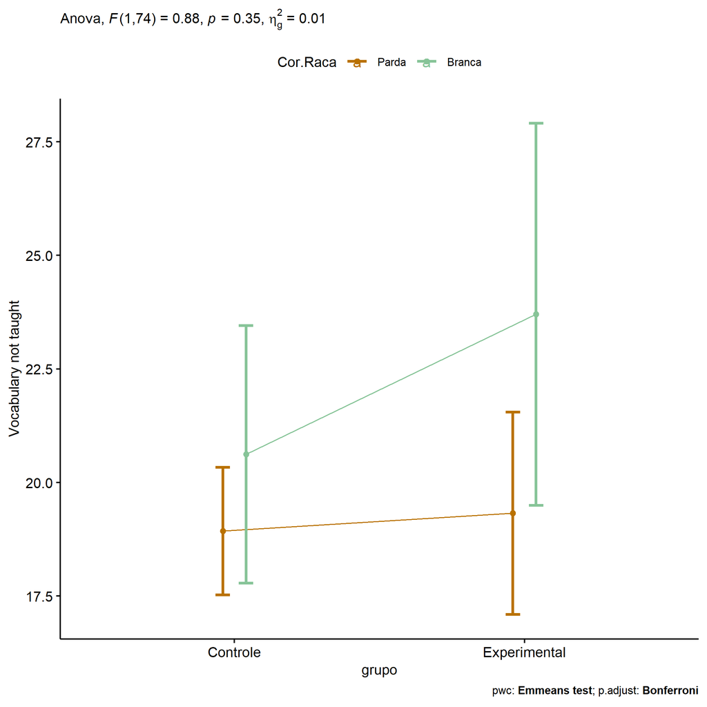

```r
if (length(unique(pdat[["Cor.Raca"]])) >= 2) {
  ggPlotAoC2(pwcs, "grupo", "Cor.Raca", aov, ylab = "Vocabulary not taught",
             subtitle = which(aov$Effect == "grupo:Cor.Raca"), addParam = "errorbar") +
    ggplot2::scale_color_manual(values = color[["Cor.Raca"]]) +
    if (ymin.ci < ymax.ci) ggplot2::ylim(ymin.ci, ymax.ci)
}
```

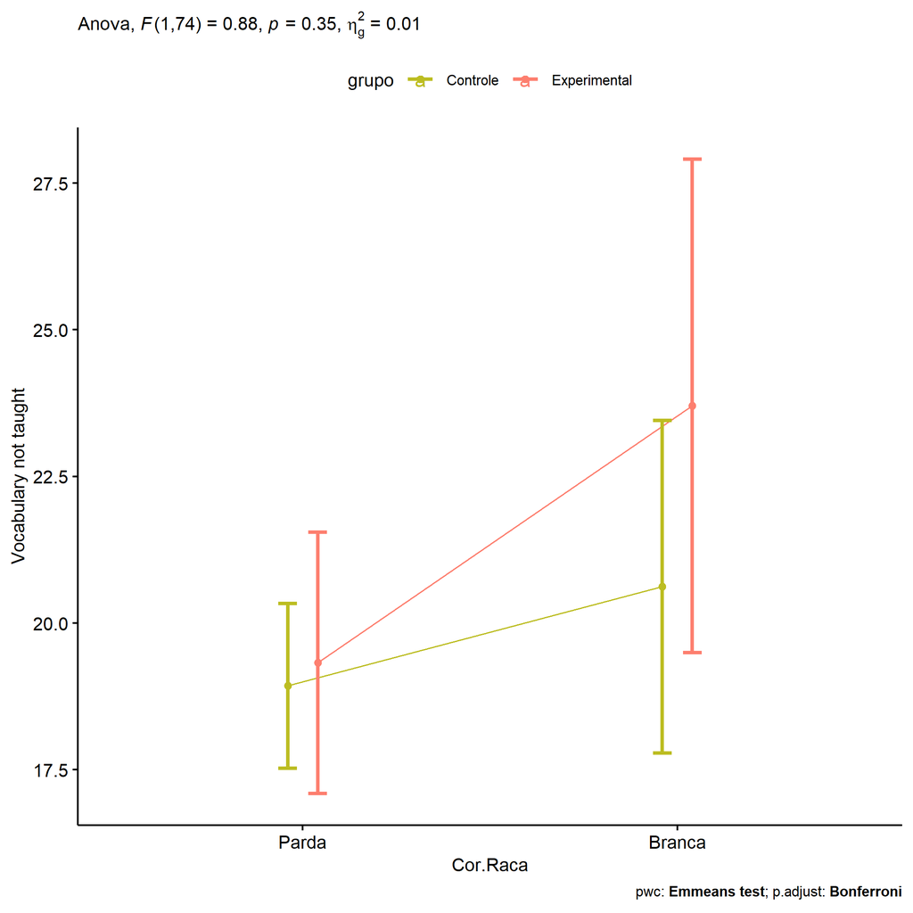

```r
if (length(unique(pdat[["Cor.Raca"]])) >= 2) {
  ggPlotAoC2(pwcs, "Cor.Raca", "grupo", aov, ylab = "Vocabulary not taught",
               subtitle = which(aov$Effect == "grupo:Cor.Raca"), addParam = "errorbar") +
      ggplot2::scale_color_manual(values = color[["grupo"]]) +
      if (ymin.ci < ymax.ci) ggplot2::ylim(ymin.ci, ymax.ci)
}
```

```r
if (length(unique(pdat[["Cor.Raca"]])) >= 2) {
  plots <- twoWayAncovaBoxPlots(
    wdat, "vocab.non.teach.pos", c("grupo","Cor.Raca"), aov, pwcs, covar = "vocab.non.teach.pre",
    theme = "classic", color = color[["grupo:Cor.Raca"]],
    subtitle = which(aov$Effect == "grupo:Cor.Raca"))
}
```

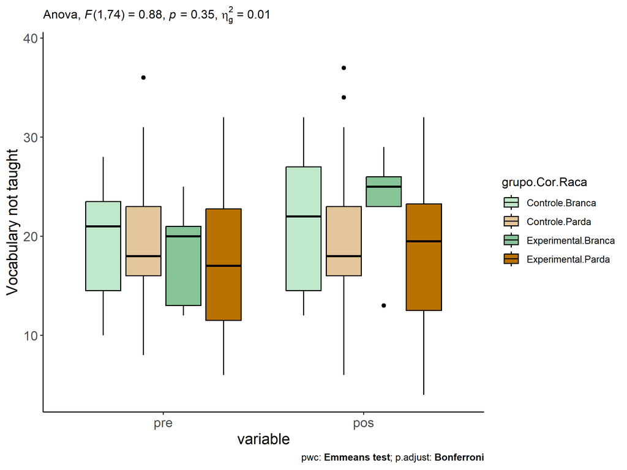

```r
if (length(unique(pdat[["Cor.Raca"]])) >= 2) {
  plots[["grupo:Cor.Raca"]] + ggplot2::ylab("Vocabulary not taught") +
  ggplot2::scale_x_discrete(labels=c('pre', 'pos')) +
  if (ymin < ymax) ggplot2::ylim(ymin, ymax)
}
```

```r
if (length(unique(pdat[["Cor.Raca"]])) >= 2) {
  plots <- twoWayAncovaBoxPlots(
    wdat.long, "vocab.non.teach", c("grupo","Cor.Raca"), aov, pwc.long,
    pre.post = "time",
    theme = "classic", color = color$prepost)
}
```

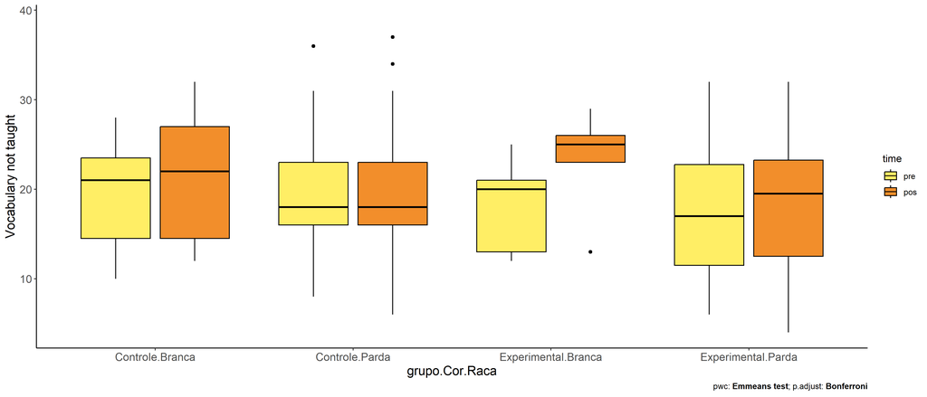

```r
if (length(unique(pdat[["Cor.Raca"]])) >= 2)
  plots[["grupo:Cor.Raca"]] + ggplot2::ylab("Vocabulary not taught") +
    if (ymin < ymax) ggplot2::ylim(ymin, ymax)
```

### Checking linearity assumption

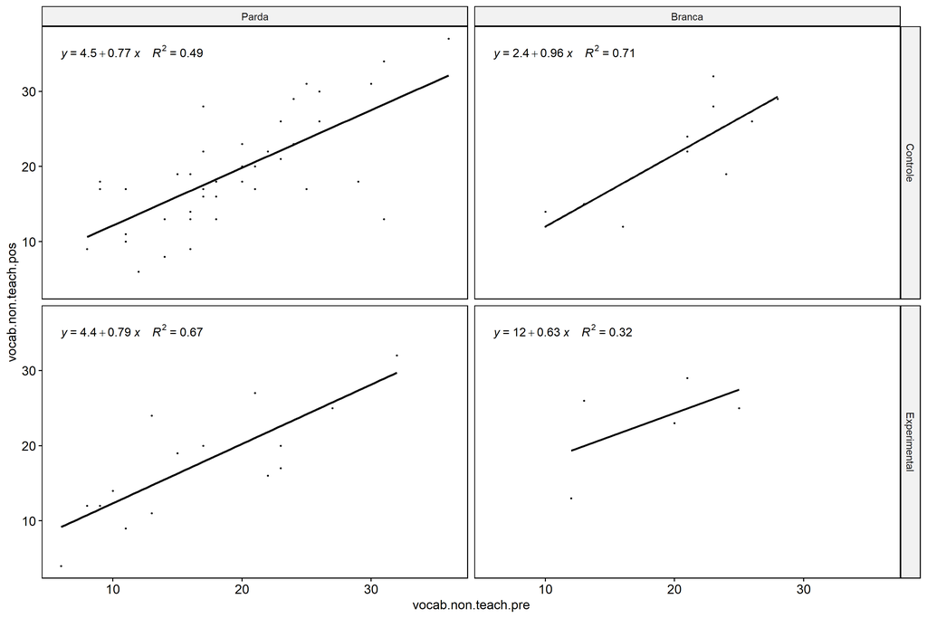

```r
if (length(unique(pdat[["Cor.Raca"]])) >= 2) {
  ggscatter(wdat, x = "vocab.non.teach.pre", y = "vocab.non.teach.pos", size = 0.5,
            facet.by = c("grupo","Cor.Raca"), add = "reg.line")+
    stat_regline_equation(
      aes(label =  paste(..eq.label.., ..rr.label.., sep = "~~~~"))
    ) +
    if (ymin < ymax) ggplot2::ylim(ymin, ymax)
}
```

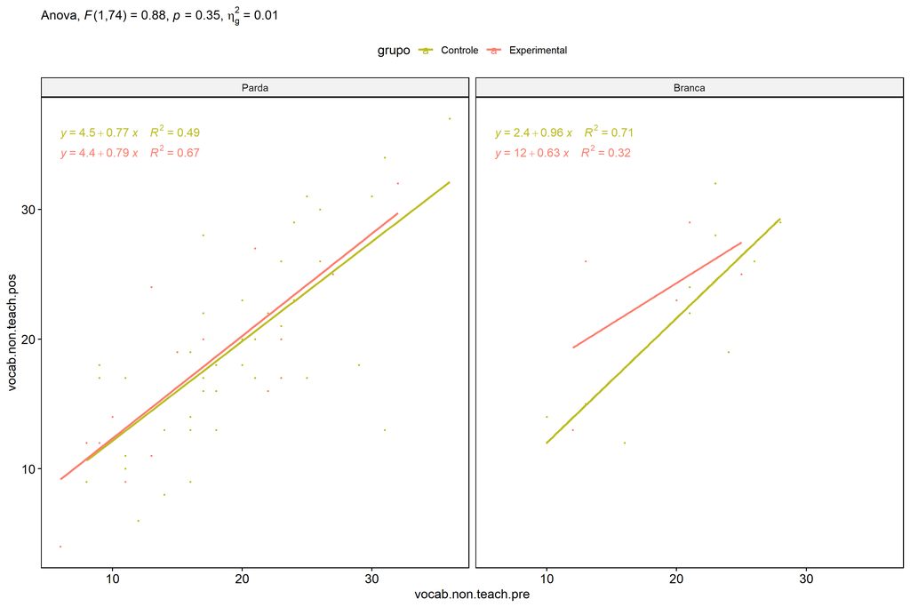

```r
if (length(unique(pdat[["Cor.Raca"]])) >= 2) {
  ggscatter(wdat, x = "vocab.non.teach.pre", y = "vocab.non.teach.pos", size = 0.5,
            color = "grupo", facet.by = "Cor.Raca", add = "reg.line")+
    stat_regline_equation(
      aes(label =  paste(..eq.label.., ..rr.label.., sep = "~~~~"), color = grupo)
    ) +
    ggplot2::labs(subtitle = rstatix::get_test_label(aov, detailed = T, row = which(aov$Effect == "grupo:Cor.Raca"))) +
    ggplot2::scale_color_manual(values = color[["grupo"]]) +
    if (ymin < ymax) ggplot2::ylim(ymin, ymax)
}
```

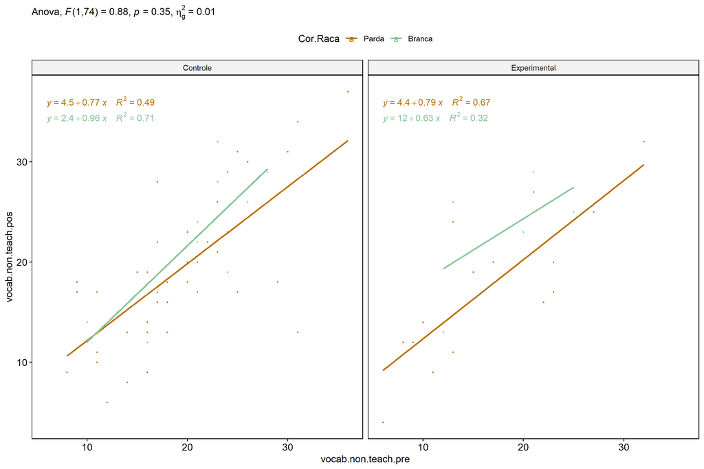

```r
if (length(unique(pdat[["Cor.Raca"]])) >= 2) {
  ggscatter(wdat, x = "vocab.non.teach.pre", y = "vocab.non.teach.pos", size = 0.5,
            color = "Cor.Raca", facet.by = "grupo", add = "reg.line")+
    stat_regline_equation(
      aes(label =  paste(..eq.label.., ..rr.label.., sep = "~~~~"), color = Cor.Raca)
    ) +
    ggplot2::labs(subtitle = rstatix::get_test_label(aov, detailed = T, row = which(aov$Effect == "grupo:Cor.Raca"))) +
    ggplot2::scale_color_manual(values = color[["Cor.Raca"]]) +
    if (ymin < ymax) ggplot2::ylim(ymin, ymax)
}
```

### Checking normality and homogeneity

```r
if (length(unique(pdat[["Cor.Raca"]])) >= 2)
  res <- augment(lm(vocab.non.teach.pos ~ vocab.non.teach.pre + grupo*Cor.Raca, data = wdat))
```

```r
if (length(unique(pdat[["Cor.Raca"]])) >= 2)
  shapiro_test(res$.resid)
```

```
## # A tibble: 1 × 3
##   variable   statistic p.value
##   <chr>          <dbl>   <dbl>
## 1 res$.resid     0.987   0.633
```

```r
if (length(unique(pdat[["Cor.Raca"]])) >= 2)
  levene_test(res, .resid ~ grupo*Cor.Raca)
```

```
## # A tibble: 1 × 4
##     df1   df2 statistic     p
##   <int> <int>     <dbl> <dbl>
## 1     3    75     0.564 0.641
```

# ANCOVA and Pairwise for two factors **grupo:Serie**

## Without remove non-normal data

```r
pdat = remove_group_data(dat[!is.na(dat[["grupo"]]) & !is.na(dat[["Serie"]]),],
                         "vocab.non.teach.pos", c("grupo","Serie"))
pdat = pdat[pdat[["Serie"]] %in% do.call(
  intersect, lapply(unique(pdat[["grupo"]]), FUN = function(x) {
    unique(pdat[["Serie"]][which(pdat[["grupo"]] == x)])
  })),]
pdat[["grupo"]] = factor(pdat[["grupo"]], level[["grupo"]])
pdat[["Serie"]] = factor(
  pdat[["Serie"]],
  level[["Serie"]][level[["Serie"]] %in% unique(pdat[["Serie"]])])

pdat.long <- rbind(pdat[,c("id","grupo","Serie")], pdat[,c("id","grupo","Serie")])
pdat.long[["time"]] <- c(rep("pre", nrow(pdat)), rep("pos", nrow(pdat)))
pdat.long[["time"]] <- factor(pdat.long[["time"]], c("pre","pos"))
pdat.long[["vocab.non.teach"]] <- c(pdat[["vocab.non.teach.pre"]], pdat[["vocab.non.teach.pos"]])

if (length(unique(pdat[["Serie"]])) >= 2) {
  aov = anova_test(pdat, vocab.non.teach.pos ~ vocab.non.teach.pre + grupo*Serie)
  laov[["grupo:Serie"]] <- get_anova_table(aov)
}
```

```r
if (length(unique(pdat[["Serie"]])) >= 2) {
  pwcs <- list()
  pwcs[["Serie"]] <- emmeans_test(
    group_by(pdat, grupo), vocab.non.teach.pos ~ Serie,
    covariate = vocab.non.teach.pre, p.adjust.method = "bonferroni")
  pwcs[["grupo"]] <- emmeans_test(
    group_by(pdat, Serie), vocab.non.teach.pos ~ grupo,
    covariate = vocab.non.teach.pre, p.adjust.method = "bonferroni")

  pwc <- plyr::rbind.fill(pwcs[["grupo"]], pwcs[["Serie"]])
  pwc <- pwc[,c("grupo","Serie", colnames(pwc)[!colnames(pwc) %in% c("grupo","Serie")])]
}
```

```r
if (length(unique(pdat[["Serie"]])) >= 2) {
  pwc.long <- emmeans_test(dplyr::group_by_at(pdat.long, c("grupo","Serie")),
                           vocab.non.teach ~ time,
                           p.adjust.method = "bonferroni")
  lpwc[["grupo:Serie"]] <- plyr::rbind.fill(pwc, pwc.long)
}
```

```r
if (length(unique(pdat[["Serie"]])) >= 2) {
  ds <- get.descriptives(pdat, "vocab.non.teach.pos", c("grupo","Serie"), covar = "vocab.non.teach.pre")
  ds <- merge(ds[ds$variable != "vocab.non.teach.pre",],
              ds[ds$variable == "vocab.non.teach.pre", !colnames(ds) %in% c("variable")],
              by = c("grupo","Serie"), all.x = T, suffixes = c("", ".vocab.non.teach.pre"))
  ds <- merge(get_emmeans(pwcs[["grupo"]]), ds,
              by = c("grupo","Serie"), suffixes = c(".emms", ""))
  ds <- ds[,c("grupo","Serie","n","mean.vocab.non.teach.pre","se.vocab.non.teach.pre","mean","se",
              "emmean","se.emms","conf.low","conf.high")]

  colnames(ds) <- c("grupo","Serie", "N", paste0(c("M","SE")," (pre)"),
                    paste0(c("M","SE"), " (unadj)"),
                    paste0(c("M", "SE"), " (adj)"), "conf.low", "conf.high")

  lemms[["grupo:Serie"]] <- ds
}
```

## Computing ANCOVA and PairWise After removing non-normal data (OK)

```r
if (length(unique(pdat[["Serie"]])) >= 2) {
  wdat = pdat

  res = residuals(lm(vocab.non.teach.pos ~ vocab.non.teach.pre + grupo*Serie, data = wdat))
  non.normal = getNonNormal(res, wdat$id, plimit = 0.05)

  wdat = wdat[!wdat$id %in% non.normal,]

  wdat.long <- rbind(wdat[,c("id","grupo","Serie")], wdat[,c("id","grupo","Serie")])
  wdat.long[["time"]] <- c(rep("pre", nrow(wdat)), rep("pos", nrow(wdat)))
  wdat.long[["time"]] <- factor(wdat.long[["time"]], c("pre","pos"))
  wdat.long[["vocab.non.teach"]] <- c(wdat[["vocab.non.teach.pre"]], wdat[["vocab.non.teach.pos"]])


  ldat[["grupo:Serie"]] = wdat

  (non.normal)
}
```

```r
if (length(unique(pdat[["Serie"]])) >= 2) {
  aov = anova_test(wdat, vocab.non.teach.pos ~ vocab.non.teach.pre + grupo*Serie)
  laov[["grupo:Serie"]] <- merge(get_anova_table(aov), laov[["grupo:Serie"]],
                                         by="Effect", suffixes = c("","'"))
  df = get_anova_table(aov)
}
```

| Effect | DFn | DFd | F | p | p<.05 | ges |
| --- | --- | --- | --- | --- | --- | --- |
| vocab.non.teach.pre | 1 | 137 | 81.871 | 0.000 | * | 0.374 |
| grupo | 1 | 137 | 0.036 | 0.851 |  | 0.000 |
| Serie | 3 | 137 | 2.674 | 0.050 | * | 0.055 |
| grupo:Serie | 3 | 137 | 1.902 | 0.132 |  | 0.040 |

```r
if (length(unique(pdat[["Serie"]])) >= 2) {
  pwcs <- list()
  pwcs[["Serie"]] <- emmeans_test(
    group_by(wdat, grupo), vocab.non.teach.pos ~ Serie,
    covariate = vocab.non.teach.pre, p.adjust.method = "bonferroni")
  pwcs[["grupo"]] <- emmeans_test(
    group_by(wdat, Serie), vocab.non.teach.pos ~ grupo,
    covariate = vocab.non.teach.pre, p.adjust.method = "bonferroni")

  pwc <- plyr::rbind.fill(pwcs[["grupo"]], pwcs[["Serie"]])
  pwc <- pwc[,c("grupo","Serie", colnames(pwc)[!colnames(pwc) %in% c("grupo","Serie")])]
}
```

| grupo | Serie | term | .y. | group1 | group2 | df | statistic | p | p.adj | p.adj.signif |
| --- | --- | --- | --- | --- | --- | --- | --- | --- | --- | --- |
|  | 6 ano | vocab.non.teach.pre*grupo | vocab.non.teach.pos | Controle | Experimental | 137 | -1.024 | 0.308 | 0.308 | ns |
|  | 7 ano | vocab.non.teach.pre*grupo | vocab.non.teach.pos | Controle | Experimental | 137 | 1.912 | 0.058 | 0.058 | ns |
|  | 8 ano | vocab.non.teach.pre*grupo | vocab.non.teach.pos | Controle | Experimental | 137 | -0.643 | 0.522 | 0.522 | ns |
|  | 9 ano | vocab.non.teach.pre*grupo | vocab.non.teach.pos | Controle | Experimental | 137 | -0.781 | 0.436 | 0.436 | ns |
| Controle |  | vocab.non.teach.pre*Serie | vocab.non.teach.pos | 6 ano | 7 ano | 137 | -3.327 | 0.001 | 0.007 | ** |
| Controle |  | vocab.non.teach.pre*Serie | vocab.non.teach.pos | 6 ano | 8 ano | 137 | -1.221 | 0.224 | 1.000 | ns |
| Controle |  | vocab.non.teach.pre*Serie | vocab.non.teach.pos | 6 ano | 9 ano | 137 | -1.952 | 0.053 | 0.318 | ns |
| Controle |  | vocab.non.teach.pre*Serie | vocab.non.teach.pos | 7 ano | 8 ano | 137 | 1.728 | 0.086 | 0.518 | ns |
| Controle |  | vocab.non.teach.pre*Serie | vocab.non.teach.pos | 7 ano | 9 ano | 137 | 1.202 | 0.232 | 1.000 | ns |
| Controle |  | vocab.non.teach.pre*Serie | vocab.non.teach.pos | 8 ano | 9 ano | 137 | -0.622 | 0.535 | 1.000 | ns |
| Experimental |  | vocab.non.teach.pre*Serie | vocab.non.teach.pos | 6 ano | 7 ano | 137 | 0.186 | 0.853 | 1.000 | ns |
| Experimental |  | vocab.non.teach.pre*Serie | vocab.non.teach.pos | 6 ano | 8 ano | 137 | -0.702 | 0.484 | 1.000 | ns |
| Experimental |  | vocab.non.teach.pre*Serie | vocab.non.teach.pos | 6 ano | 9 ano | 137 | -1.221 | 0.224 | 1.000 | ns |
| Experimental |  | vocab.non.teach.pre*Serie | vocab.non.teach.pos | 7 ano | 8 ano | 137 | -0.889 | 0.376 | 1.000 | ns |
| Experimental |  | vocab.non.teach.pre*Serie | vocab.non.teach.pos | 7 ano | 9 ano | 137 | -1.387 | 0.168 | 1.000 | ns |
| Experimental |  | vocab.non.teach.pre*Serie | vocab.non.teach.pos | 8 ano | 9 ano | 137 | -0.630 | 0.530 | 1.000 | ns |

```r
if (length(unique(pdat[["Serie"]])) >= 2) {
  pwc.long <- emmeans_test(dplyr::group_by_at(wdat.long, c("grupo","Serie")),
                           vocab.non.teach ~ time,
                           p.adjust.method = "bonferroni")
  lpwc[["grupo:Serie"]] <- merge(plyr::rbind.fill(pwc, pwc.long),
                                         lpwc[["grupo:Serie"]],
                                         by=c("grupo","Serie","term",".y.","group1","group2"),
                                         suffixes = c("","'"))
}
```

| grupo | Serie | term | .y. | group1 | group2 | df | statistic | p | p.adj | p.adj.signif |
| --- | --- | --- | --- | --- | --- | --- | --- | --- | --- | --- |
| Controle | 6 ano | time | vocab.non.teach | pre | pos | 276 | 0.505 | 0.614 | 0.614 | ns |
| Controle | 7 ano | time | vocab.non.teach | pre | pos | 276 | -1.672 | 0.096 | 0.096 | ns |
| Controle | 8 ano | time | vocab.non.teach | pre | pos | 276 | 0.109 | 0.914 | 0.914 | ns |
| Controle | 9 ano | time | vocab.non.teach | pre | pos | 276 | 0.366 | 0.714 | 0.714 | ns |
| Experimental | 6 ano | time | vocab.non.teach | pre | pos | 276 | -0.062 | 0.950 | 0.950 | ns |
| Experimental | 7 ano | time | vocab.non.teach | pre | pos | 276 | 0.373 | 0.710 | 0.710 | ns |
| Experimental | 8 ano | time | vocab.non.teach | pre | pos | 276 | -0.659 | 0.511 | 0.511 | ns |
| Experimental | 9 ano | time | vocab.non.teach | pre | pos | 276 | -0.673 | 0.501 | 0.501 | ns |

```r
if (length(unique(pdat[["Serie"]])) >= 2) {
  ds <- get.descriptives(wdat, "vocab.non.teach.pos", c("grupo","Serie"), covar = "vocab.non.teach.pre")
  ds <- merge(ds[ds$variable != "vocab.non.teach.pre",],
              ds[ds$variable == "vocab.non.teach.pre", !colnames(ds) %in% c("variable")],
              by = c("grupo","Serie"), all.x = T, suffixes = c("", ".vocab.non.teach.pre"))
  ds <- merge(get_emmeans(pwcs[["grupo"]]), ds,
              by = c("grupo","Serie"), suffixes = c(".emms", ""))
  ds <- ds[,c("grupo","Serie","n","mean.vocab.non.teach.pre","se.vocab.non.teach.pre",
              "mean","se","emmean","se.emms","conf.low","conf.high")]

  colnames(ds) <- c("grupo","Serie", "N", paste0(c("M","SE")," (pre)"),
                    paste0(c("M","SE"), " (unadj)"),
                    paste0(c("M", "SE"), " (adj)"), "conf.low", "conf.high")

  lemms[["grupo:Serie"]] <- merge(ds, lemms[["grupo:Serie"]],
                                          by=c("grupo","Serie"), suffixes = c("","'"))
}
```

| grupo | Serie | N | M (pre) | SE (pre) | M (unadj) | SE (unadj) | M (adj) | SE (adj) | conf.low | conf.high |
| --- | --- | --- | --- | --- | --- | --- | --- | --- | --- | --- |
| Controle | 6 ano | 26 | 15.962 | 0.950 | 15.077 | 0.906 | 17.568 | 1.060 | 15.472 | 19.663 |
| Controle | 7 ano | 28 | 19.214 | 0.996 | 22.036 | 1.334 | 22.363 | 0.987 | 20.411 | 24.314 |
| Controle | 8 ano | 17 | 20.059 | 2.066 | 19.824 | 1.961 | 19.588 | 1.266 | 17.085 | 22.092 |
| Controle | 9 ano | 27 | 24.296 | 1.082 | 23.667 | 1.280 | 20.612 | 1.060 | 18.517 | 22.707 |
| Experimental | 6 ano | 13 | 18.308 | 1.685 | 18.462 | 1.616 | 19.391 | 1.451 | 16.522 | 22.261 |
| Experimental | 7 ano | 13 | 20.385 | 1.862 | 19.462 | 2.046 | 19.010 | 1.448 | 16.146 | 21.873 |
| Experimental | 8 ano | 14 | 18.286 | 1.906 | 19.857 | 1.872 | 20.802 | 1.399 | 18.036 | 23.567 |
| Experimental | 9 ano | 8 | 21.000 | 1.134 | 23.125 | 1.827 | 22.264 | 1.847 | 18.611 | 25.917 |

### Plots for ancova

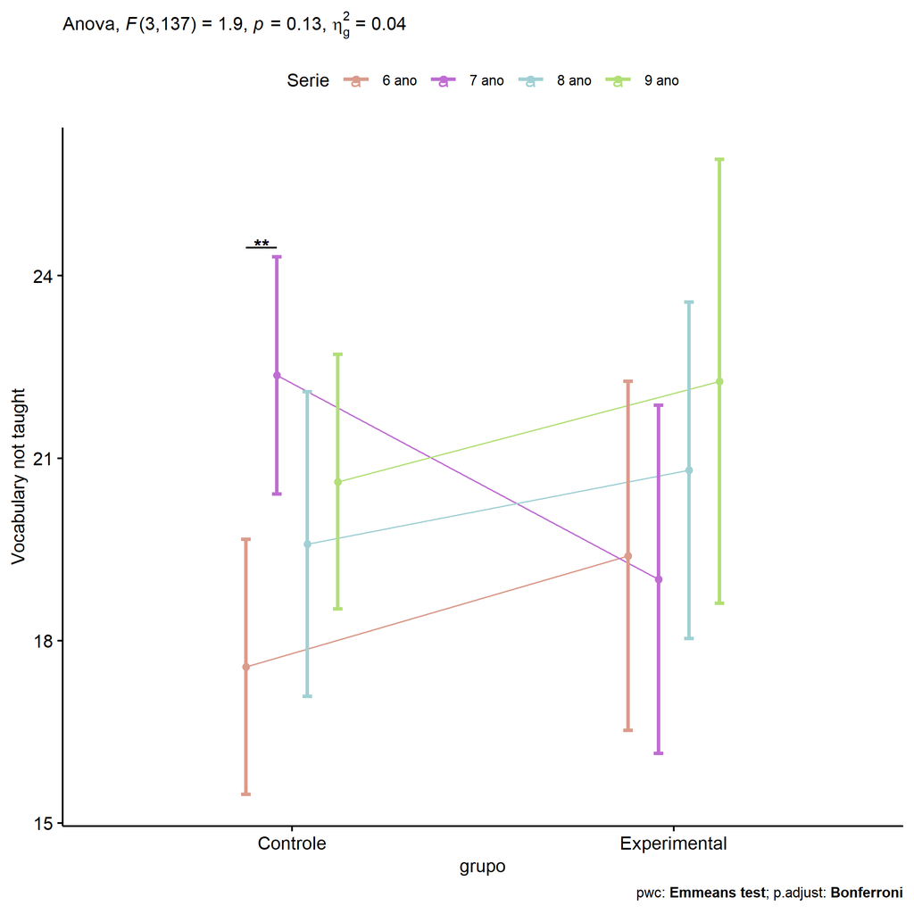

```r
if (length(unique(pdat[["Serie"]])) >= 2) {
  ggPlotAoC2(pwcs, "grupo", "Serie", aov, ylab = "Vocabulary not taught",
             subtitle = which(aov$Effect == "grupo:Serie"), addParam = "errorbar") +
    ggplot2::scale_color_manual(values = color[["Serie"]]) +
    if (ymin.ci < ymax.ci) ggplot2::ylim(ymin.ci, ymax.ci)
}
```

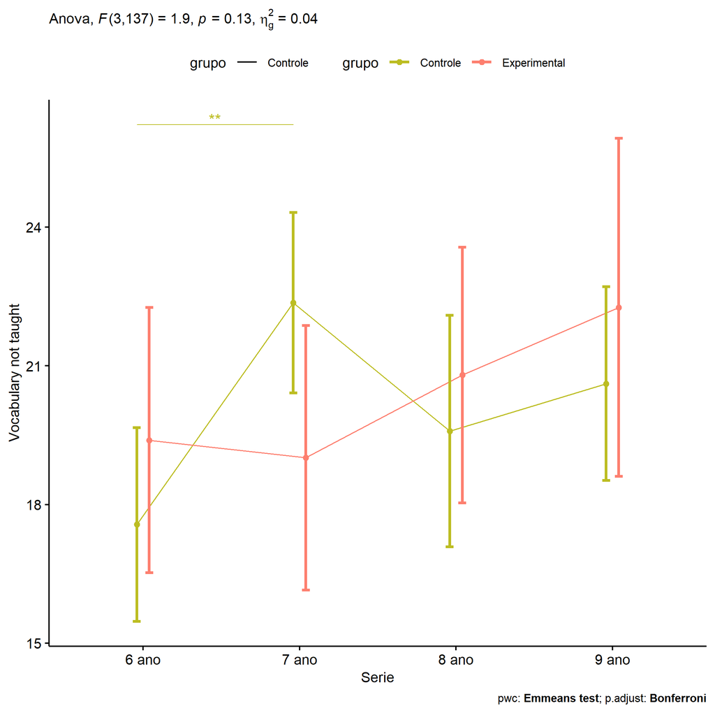

```r
if (length(unique(pdat[["Serie"]])) >= 2) {
  ggPlotAoC2(pwcs, "Serie", "grupo", aov, ylab = "Vocabulary not taught",
               subtitle = which(aov$Effect == "grupo:Serie"), addParam = "errorbar") +
      ggplot2::scale_color_manual(values = color[["grupo"]]) +
      if (ymin.ci < ymax.ci) ggplot2::ylim(ymin.ci, ymax.ci)
}
```

```r
if (length(unique(pdat[["Serie"]])) >= 2) {
  plots <- twoWayAncovaBoxPlots(
    wdat, "vocab.non.teach.pos", c("grupo","Serie"), aov, pwcs, covar = "vocab.non.teach.pre",
    theme = "classic", color = color[["grupo:Serie"]],
    subtitle = which(aov$Effect == "grupo:Serie"))
}
```

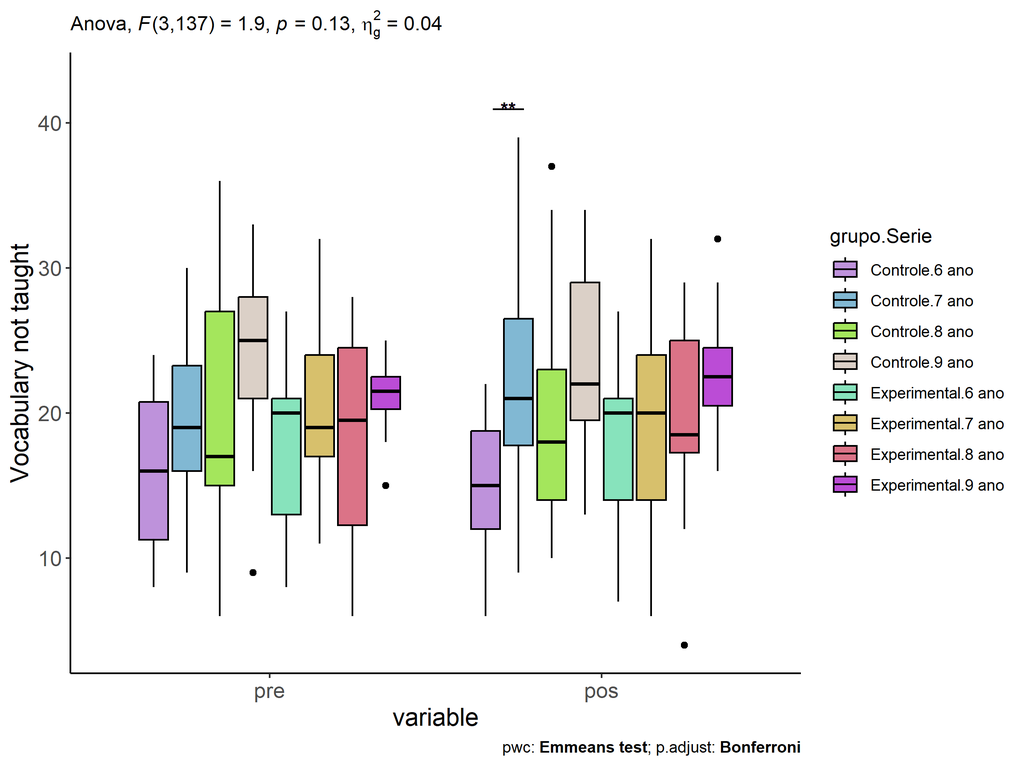

```r
if (length(unique(pdat[["Serie"]])) >= 2) {
  plots[["grupo:Serie"]] + ggplot2::ylab("Vocabulary not taught") +
  ggplot2::scale_x_discrete(labels=c('pre', 'pos')) +
  if (ymin < ymax) ggplot2::ylim(ymin, ymax)
}
```

```r
if (length(unique(pdat[["Serie"]])) >= 2) {
  plots <- twoWayAncovaBoxPlots(
    wdat.long, "vocab.non.teach", c("grupo","Serie"), aov, pwc.long,
    pre.post = "time",
    theme = "classic", color = color$prepost)
}
```

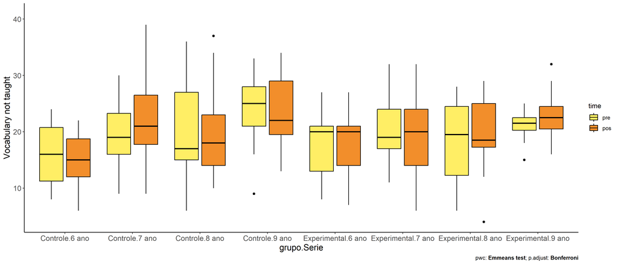

```r
if (length(unique(pdat[["Serie"]])) >= 2)
  plots[["grupo:Serie"]] + ggplot2::ylab("Vocabulary not taught") +
    if (ymin < ymax) ggplot2::ylim(ymin, ymax)
```

### Checking linearity assumption

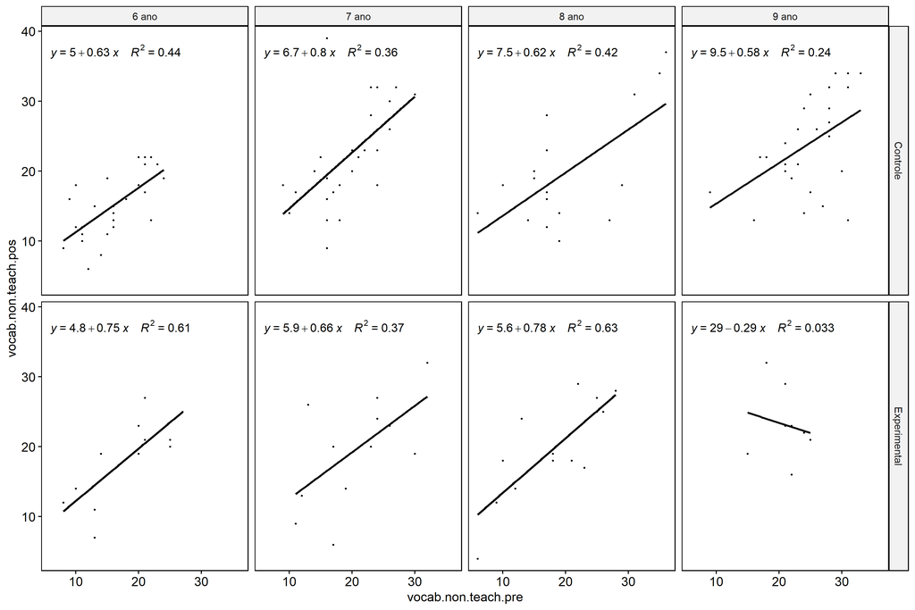

```r
if (length(unique(pdat[["Serie"]])) >= 2) {
  ggscatter(wdat, x = "vocab.non.teach.pre", y = "vocab.non.teach.pos", size = 0.5,
            facet.by = c("grupo","Serie"), add = "reg.line")+
    stat_regline_equation(
      aes(label =  paste(..eq.label.., ..rr.label.., sep = "~~~~"))
    ) +
    if (ymin < ymax) ggplot2::ylim(ymin, ymax)
}
```

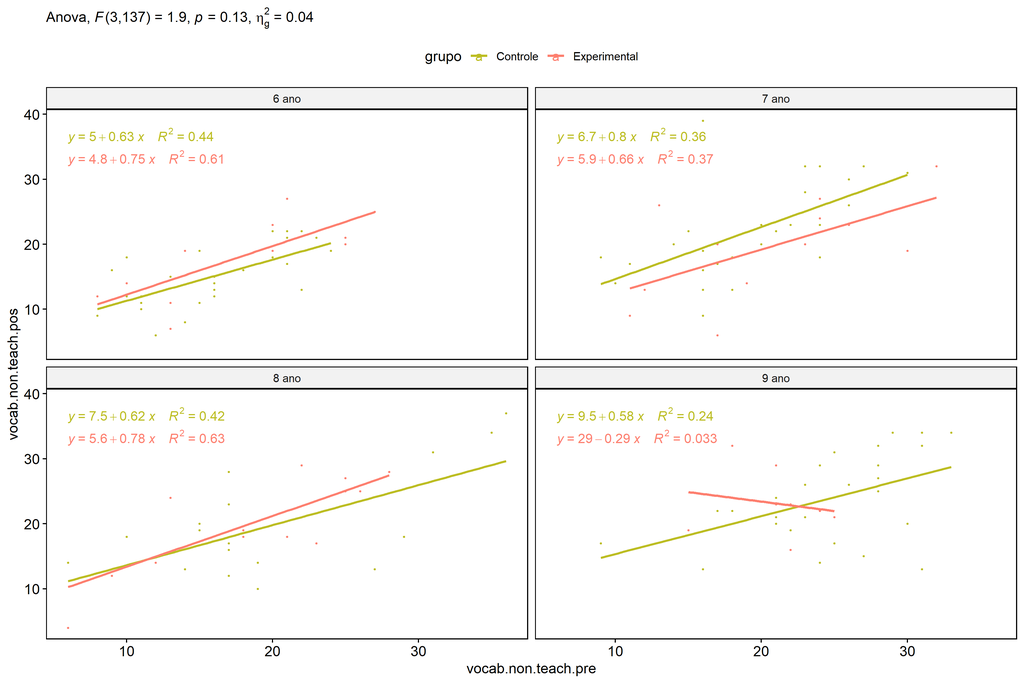

```r
if (length(unique(pdat[["Serie"]])) >= 2) {
  ggscatter(wdat, x = "vocab.non.teach.pre", y = "vocab.non.teach.pos", size = 0.5,
            color = "grupo", facet.by = "Serie", add = "reg.line")+
    stat_regline_equation(
      aes(label =  paste(..eq.label.., ..rr.label.., sep = "~~~~"), color = grupo)
    ) +
    ggplot2::labs(subtitle = rstatix::get_test_label(aov, detailed = T, row = which(aov$Effect == "grupo:Serie"))) +
    ggplot2::scale_color_manual(values = color[["grupo"]]) +
    if (ymin < ymax) ggplot2::ylim(ymin, ymax)
}
```

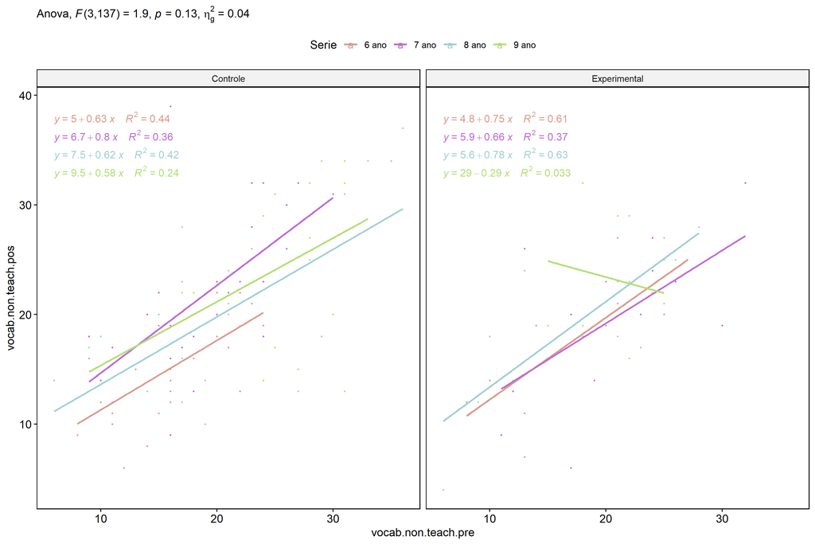

```r
if (length(unique(pdat[["Serie"]])) >= 2) {
  ggscatter(wdat, x = "vocab.non.teach.pre", y = "vocab.non.teach.pos", size = 0.5,
            color = "Serie", facet.by = "grupo", add = "reg.line")+
    stat_regline_equation(
      aes(label =  paste(..eq.label.., ..rr.label.., sep = "~~~~"), color = Serie)
    ) +
    ggplot2::labs(subtitle = rstatix::get_test_label(aov, detailed = T, row = which(aov$Effect == "grupo:Serie"))) +
    ggplot2::scale_color_manual(values = color[["Serie"]]) +
    if (ymin < ymax) ggplot2::ylim(ymin, ymax)
}
```

### Checking normality and homogeneity

```r
if (length(unique(pdat[["Serie"]])) >= 2)
  res <- augment(lm(vocab.non.teach.pos ~ vocab.non.teach.pre + grupo*Serie, data = wdat))
```

```r
if (length(unique(pdat[["Serie"]])) >= 2)
  shapiro_test(res$.resid)
```

```
## # A tibble: 1 × 3
##   variable   statistic p.value
##   <chr>          <dbl>   <dbl>
## 1 res$.resid     0.984  0.0865
```

```r
if (length(unique(pdat[["Serie"]])) >= 2)
  levene_test(res, .resid ~ grupo*Serie)
```

```
## # A tibble: 1 × 4
##     df1   df2 statistic     p
##   <int> <int>     <dbl> <dbl>
## 1     7   138      1.11 0.361
```

# ANCOVA and Pairwise for two factors **grupo:vocab.non.teach.quintile**

## Without remove non-normal data

```r
pdat = remove_group_data(dat[!is.na(dat[["grupo"]]) & !is.na(dat[["vocab.non.teach.quintile"]]),],
                         "vocab.non.teach.pos", c("grupo","vocab.non.teach.quintile"))
pdat = pdat[pdat[["vocab.non.teach.quintile"]] %in% do.call(
  intersect, lapply(unique(pdat[["grupo"]]), FUN = function(x) {
    unique(pdat[["vocab.non.teach.quintile"]][which(pdat[["grupo"]] == x)])
  })),]
pdat[["grupo"]] = factor(pdat[["grupo"]], level[["grupo"]])
pdat[["vocab.non.teach.quintile"]] = factor(
  pdat[["vocab.non.teach.quintile"]],
  level[["vocab.non.teach.quintile"]][level[["vocab.non.teach.quintile"]] %in% unique(pdat[["vocab.non.teach.quintile"]])])

pdat.long <- rbind(pdat[,c("id","grupo","vocab.non.teach.quintile")], pdat[,c("id","grupo","vocab.non.teach.quintile")])
pdat.long[["time"]] <- c(rep("pre", nrow(pdat)), rep("pos", nrow(pdat)))
pdat.long[["time"]] <- factor(pdat.long[["time"]], c("pre","pos"))
pdat.long[["vocab.non.teach"]] <- c(pdat[["vocab.non.teach.pre"]], pdat[["vocab.non.teach.pos"]])

if (length(unique(pdat[["vocab.non.teach.quintile"]])) >= 2) {
  aov = anova_test(pdat, vocab.non.teach.pos ~ vocab.non.teach.pre + grupo*vocab.non.teach.quintile)
  laov[["grupo:vocab.non.teach.quintile"]] <- get_anova_table(aov)
}
```

```r
if (length(unique(pdat[["vocab.non.teach.quintile"]])) >= 2) {
  pwcs <- list()
  pwcs[["vocab.non.teach.quintile"]] <- emmeans_test(
    group_by(pdat, grupo), vocab.non.teach.pos ~ vocab.non.teach.quintile,
    covariate = vocab.non.teach.pre, p.adjust.method = "bonferroni")
  pwcs[["grupo"]] <- emmeans_test(
    group_by(pdat, vocab.non.teach.quintile), vocab.non.teach.pos ~ grupo,
    covariate = vocab.non.teach.pre, p.adjust.method = "bonferroni")

  pwc <- plyr::rbind.fill(pwcs[["grupo"]], pwcs[["vocab.non.teach.quintile"]])
  pwc <- pwc[,c("grupo","vocab.non.teach.quintile", colnames(pwc)[!colnames(pwc) %in% c("grupo","vocab.non.teach.quintile")])]
}
```

```r
if (length(unique(pdat[["vocab.non.teach.quintile"]])) >= 2) {
  pwc.long <- emmeans_test(dplyr::group_by_at(pdat.long, c("grupo","vocab.non.teach.quintile")),
                           vocab.non.teach ~ time,
                           p.adjust.method = "bonferroni")
  lpwc[["grupo:vocab.non.teach.quintile"]] <- plyr::rbind.fill(pwc, pwc.long)
}
```

```r
if (length(unique(pdat[["vocab.non.teach.quintile"]])) >= 2) {
  ds <- get.descriptives(pdat, "vocab.non.teach.pos", c("grupo","vocab.non.teach.quintile"), covar = "vocab.non.teach.pre")
  ds <- merge(ds[ds$variable != "vocab.non.teach.pre",],
              ds[ds$variable == "vocab.non.teach.pre", !colnames(ds) %in% c("variable")],
              by = c("grupo","vocab.non.teach.quintile"), all.x = T, suffixes = c("", ".vocab.non.teach.pre"))
  ds <- merge(get_emmeans(pwcs[["grupo"]]), ds,
              by = c("grupo","vocab.non.teach.quintile"), suffixes = c(".emms", ""))
  ds <- ds[,c("grupo","vocab.non.teach.quintile","n","mean.vocab.non.teach.pre","se.vocab.non.teach.pre","mean","se",
              "emmean","se.emms","conf.low","conf.high")]

  colnames(ds) <- c("grupo","vocab.non.teach.quintile", "N", paste0(c("M","SE")," (pre)"),
                    paste0(c("M","SE"), " (unadj)"),
                    paste0(c("M", "SE"), " (adj)"), "conf.low", "conf.high")

  lemms[["grupo:vocab.non.teach.quintile"]] <- ds
}
```

## Computing ANCOVA and PairWise After removing non-normal data (OK)

```r
if (length(unique(pdat[["vocab.non.teach.quintile"]])) >= 2) {
  wdat = pdat

  res = residuals(lm(vocab.non.teach.pos ~ vocab.non.teach.pre + grupo*vocab.non.teach.quintile, data = wdat))
  non.normal = getNonNormal(res, wdat$id, plimit = 0.05)

  wdat = wdat[!wdat$id %in% non.normal,]

  wdat.long <- rbind(wdat[,c("id","grupo","vocab.non.teach.quintile")], wdat[,c("id","grupo","vocab.non.teach.quintile")])
  wdat.long[["time"]] <- c(rep("pre", nrow(wdat)), rep("pos", nrow(wdat)))
  wdat.long[["time"]] <- factor(wdat.long[["time"]], c("pre","pos"))
  wdat.long[["vocab.non.teach"]] <- c(wdat[["vocab.non.teach.pre"]], wdat[["vocab.non.teach.pos"]])


  ldat[["grupo:vocab.non.teach.quintile"]] = wdat

  (non.normal)
}
```

```
## [1] "P3569"
```

```r
if (length(unique(pdat[["vocab.non.teach.quintile"]])) >= 2) {
  aov = anova_test(wdat, vocab.non.teach.pos ~ vocab.non.teach.pre + grupo*vocab.non.teach.quintile)
  laov[["grupo:vocab.non.teach.quintile"]] <- merge(get_anova_table(aov), laov[["grupo:vocab.non.teach.quintile"]],
                                         by="Effect", suffixes = c("","'"))
  df = get_anova_table(aov)
}
```

| Effect | DFn | DFd | F | p | p<.05 | ges |
| --- | --- | --- | --- | --- | --- | --- |
| vocab.non.teach.pre | 1 | 125 | 3.099 | 0.081 |  | 0.024 |
| grupo | 1 | 125 | 0.138 | 0.711 |  | 0.001 |
| vocab.non.teach.quintile | 3 | 125 | 0.666 | 0.575 |  | 0.016 |
| grupo:vocab.non.teach.quintile | 3 | 125 | 0.380 | 0.768 |  | 0.009 |

```r
if (length(unique(pdat[["vocab.non.teach.quintile"]])) >= 2) {
  pwcs <- list()
  pwcs[["vocab.non.teach.quintile"]] <- emmeans_test(
    group_by(wdat, grupo), vocab.non.teach.pos ~ vocab.non.teach.quintile,
    covariate = vocab.non.teach.pre, p.adjust.method = "bonferroni")
  pwcs[["grupo"]] <- emmeans_test(
    group_by(wdat, vocab.non.teach.quintile), vocab.non.teach.pos ~ grupo,
    covariate = vocab.non.teach.pre, p.adjust.method = "bonferroni")

  pwc <- plyr::rbind.fill(pwcs[["grupo"]], pwcs[["vocab.non.teach.quintile"]])
  pwc <- pwc[,c("grupo","vocab.non.teach.quintile", colnames(pwc)[!colnames(pwc) %in% c("grupo","vocab.non.teach.quintile")])]
}
```

| grupo | vocab.non.teach.quintile | term | .y. | group1 | group2 | df | statistic | p | p.adj | p.adj.signif |
| --- | --- | --- | --- | --- | --- | --- | --- | --- | --- | --- |
|  | 1st quintile | vocab.non.teach.pre*grupo | vocab.non.teach.pos | Controle | Experimental | 125 | 0.290 | 0.772 | 0.772 | ns |
|  | 2nd quintile | vocab.non.teach.pre*grupo | vocab.non.teach.pos | Controle | Experimental | 125 | -0.966 | 0.336 | 0.336 | ns |
|  | 3rd quintile | vocab.non.teach.pre*grupo | vocab.non.teach.pos | Controle | Experimental | 125 | -0.345 | 0.731 | 0.731 | ns |
|  | 4th quintile | vocab.non.teach.pre*grupo | vocab.non.teach.pos | Controle | Experimental | 125 | 0.375 | 0.708 | 0.708 | ns |
| Controle |  | vocab.non.teach.pre*vocab.non.teach.quintile | vocab.non.teach.pos | 1st quintile | 2nd quintile | 125 | 0.267 | 0.790 | 1.000 | ns |
| Controle |  | vocab.non.teach.pre*vocab.non.teach.quintile | vocab.non.teach.pos | 1st quintile | 3rd quintile | 125 | -0.524 | 0.601 | 1.000 | ns |
| Controle |  | vocab.non.teach.pre*vocab.non.teach.quintile | vocab.non.teach.pos | 1st quintile | 4th quintile | 125 | -0.530 | 0.597 | 1.000 | ns |
| Controle |  | vocab.non.teach.pre*vocab.non.teach.quintile | vocab.non.teach.pos | 2nd quintile | 3rd quintile | 125 | -1.270 | 0.207 | 1.000 | ns |
| Controle |  | vocab.non.teach.pre*vocab.non.teach.quintile | vocab.non.teach.pos | 2nd quintile | 4th quintile | 125 | -0.986 | 0.326 | 1.000 | ns |
| Controle |  | vocab.non.teach.pre*vocab.non.teach.quintile | vocab.non.teach.pos | 3rd quintile | 4th quintile | 125 | -0.362 | 0.718 | 1.000 | ns |
| Experimental |  | vocab.non.teach.pre*vocab.non.teach.quintile | vocab.non.teach.pos | 1st quintile | 2nd quintile | 125 | -0.612 | 0.542 | 1.000 | ns |
| Experimental |  | vocab.non.teach.pre*vocab.non.teach.quintile | vocab.non.teach.pos | 1st quintile | 3rd quintile | 125 | -0.835 | 0.405 | 1.000 | ns |
| Experimental |  | vocab.non.teach.pre*vocab.non.teach.quintile | vocab.non.teach.pos | 1st quintile | 4th quintile | 125 | -0.527 | 0.599 | 1.000 | ns |
| Experimental |  | vocab.non.teach.pre*vocab.non.teach.quintile | vocab.non.teach.pos | 2nd quintile | 3rd quintile | 125 | -0.553 | 0.581 | 1.000 | ns |
| Experimental |  | vocab.non.teach.pre*vocab.non.teach.quintile | vocab.non.teach.pos | 2nd quintile | 4th quintile | 125 | -0.241 | 0.810 | 1.000 | ns |
| Experimental |  | vocab.non.teach.pre*vocab.non.teach.quintile | vocab.non.teach.pos | 3rd quintile | 4th quintile | 125 | 0.233 | 0.816 | 1.000 | ns |

```r
if (length(unique(pdat[["vocab.non.teach.quintile"]])) >= 2) {
  pwc.long <- emmeans_test(dplyr::group_by_at(wdat.long, c("grupo","vocab.non.teach.quintile")),
                           vocab.non.teach ~ time,
                           p.adjust.method = "bonferroni")
  lpwc[["grupo:vocab.non.teach.quintile"]] <- merge(plyr::rbind.fill(pwc, pwc.long),
                                         lpwc[["grupo:vocab.non.teach.quintile"]],
                                         by=c("grupo","vocab.non.teach.quintile","term",".y.","group1","group2"),
                                         suffixes = c("","'"))
}
```

| grupo | vocab.non.teach.quintile | term | .y. | group1 | group2 | df | statistic | p | p.adj | p.adj.signif |
| --- | --- | --- | --- | --- | --- | --- | --- | --- | --- | --- |
| Controle | 1st quintile | time | vocab.non.teach | pre | pos | 252 | -2.822 | 0.005 | 0.005 | ** |
| Controle | 2nd quintile | time | vocab.non.teach | pre | pos | 252 | -0.068 | 0.946 | 0.946 | ns |
| Controle | 3rd quintile | time | vocab.non.teach | pre | pos | 252 | 0.037 | 0.971 | 0.971 | ns |
| Controle | 4th quintile | time | vocab.non.teach | pre | pos | 252 | 1.230 | 0.220 | 0.220 | ns |
| Experimental | 1st quintile | time | vocab.non.teach | pre | pos | 252 | -1.882 | 0.061 | 0.061 | ns |
| Experimental | 2nd quintile | time | vocab.non.teach | pre | pos | 252 | -0.895 | 0.372 | 0.372 | ns |
| Experimental | 3rd quintile | time | vocab.non.teach | pre | pos | 252 | -0.431 | 0.667 | 0.667 | ns |
| Experimental | 4th quintile | time | vocab.non.teach | pre | pos | 252 | 1.087 | 0.278 | 0.278 | ns |

```r
if (length(unique(pdat[["vocab.non.teach.quintile"]])) >= 2) {
  ds <- get.descriptives(wdat, "vocab.non.teach.pos", c("grupo","vocab.non.teach.quintile"), covar = "vocab.non.teach.pre")
  ds <- merge(ds[ds$variable != "vocab.non.teach.pre",],
              ds[ds$variable == "vocab.non.teach.pre", !colnames(ds) %in% c("variable")],
              by = c("grupo","vocab.non.teach.quintile"), all.x = T, suffixes = c("", ".vocab.non.teach.pre"))
  ds <- merge(get_emmeans(pwcs[["grupo"]]), ds,
              by = c("grupo","vocab.non.teach.quintile"), suffixes = c(".emms", ""))
  ds <- ds[,c("grupo","vocab.non.teach.quintile","n","mean.vocab.non.teach.pre","se.vocab.non.teach.pre",
              "mean","se","emmean","se.emms","conf.low","conf.high")]

  colnames(ds) <- c("grupo","vocab.non.teach.quintile", "N", paste0(c("M","SE")," (pre)"),
                    paste0(c("M","SE"), " (unadj)"),
                    paste0(c("M", "SE"), " (adj)"), "conf.low", "conf.high")

  lemms[["grupo:vocab.non.teach.quintile"]] <- merge(ds, lemms[["grupo:vocab.non.teach.quintile"]],
                                          by=c("grupo","vocab.non.teach.quintile"), suffixes = c("","'"))
}
```

| grupo | vocab.non.teach.quintile | N | M (pre) | SE (pre) | M (unadj) | SE (unadj) | M (adj) | SE (adj) | conf.low | conf.high |
| --- | --- | --- | --- | --- | --- | --- | --- | --- | --- | --- |
| Controle | 1st quintile | 15 | 10.000 | 0.436 | 13.800 | 0.957 | 18.278 | 2.847 | 12.644 | 23.912 |
| Controle | 2nd quintile | 32 | 16.344 | 0.236 | 16.406 | 0.819 | 17.634 | 1.119 | 15.420 | 19.848 |
| Controle | 3rd quintile | 27 | 22.000 | 0.282 | 21.963 | 0.878 | 20.292 | 1.345 | 17.630 | 22.953 |
| Controle | 4th quintile | 14 | 27.071 | 0.355 | 25.357 | 1.842 | 21.087 | 2.763 | 15.619 | 26.555 |
| Experimental | 1st quintile | 12 | 10.833 | 0.661 | 13.667 | 1.848 | 17.718 | 2.709 | 12.357 | 23.079 |
| Experimental | 2nd quintile | 9 | 17.000 | 0.527 | 18.556 | 2.249 | 19.447 | 1.726 | 16.031 | 22.862 |
| Experimental | 3rd quintile | 16 | 21.875 | 0.340 | 22.438 | 1.008 | 20.830 | 1.538 | 17.787 | 23.874 |
| Experimental | 4th quintile | 9 | 25.778 | 0.364 | 23.889 | 0.935 | 20.282 | 2.631 | 15.076 | 25.488 |